# Interactive effect of temp and land use on nestling growth, nestling cort, and adult visitation rate

2025-02-25

## Why was there no provisioning before 11am?

Previously, we noticed there was a strange cutoff for provisioning. It was an accidental result of the temp matching process - time zone was not handled properly and so temps were matched to the wrong times.

### Provis by time of day: WEBL, 1h

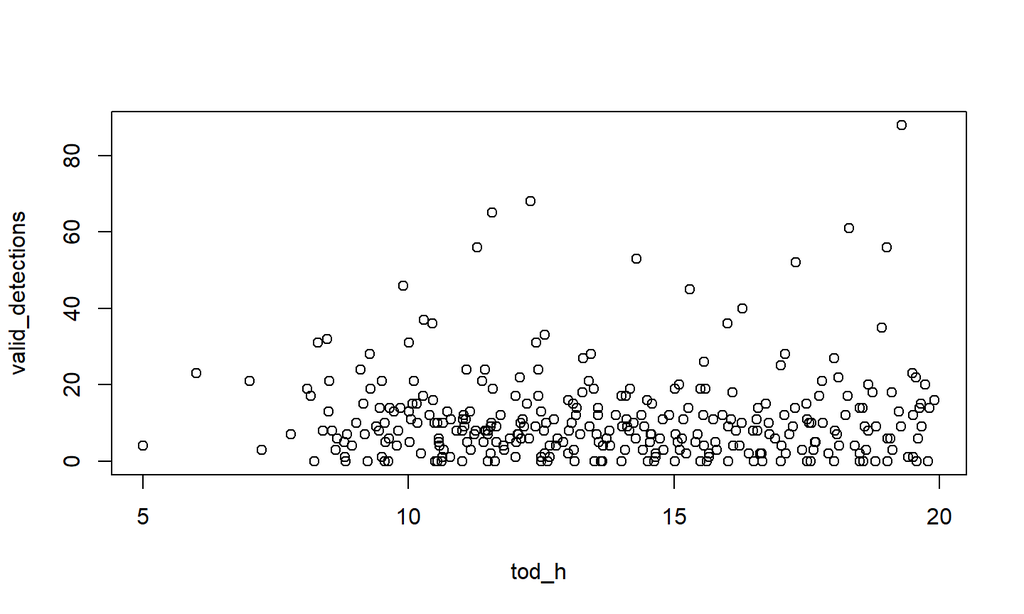

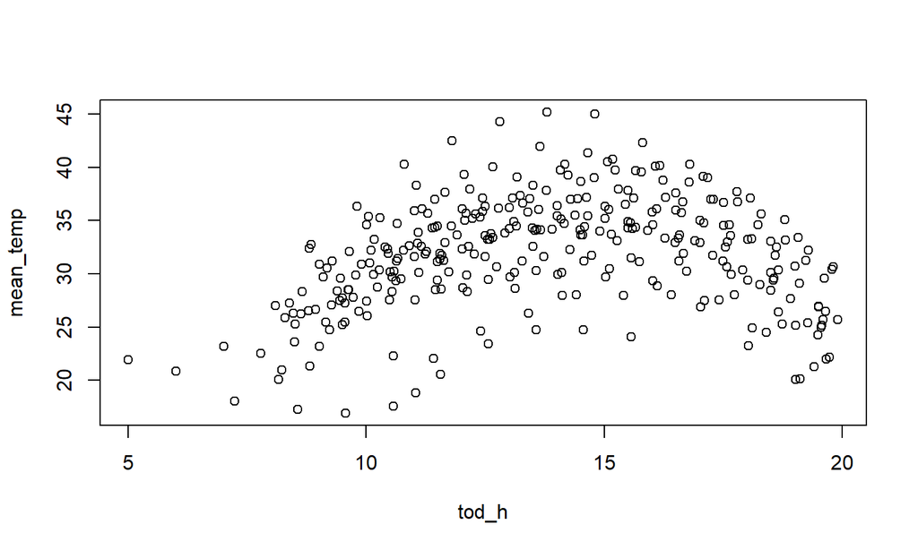

So now provisioning and temp actually both line up in a way that seems reasonable. Yay!

### Provis by time of day: TRES

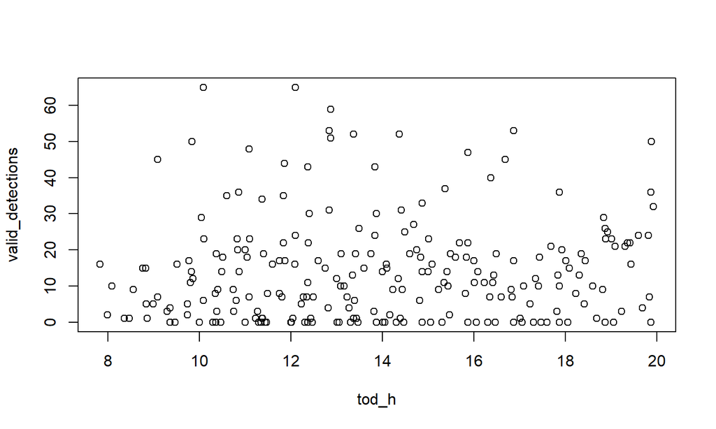

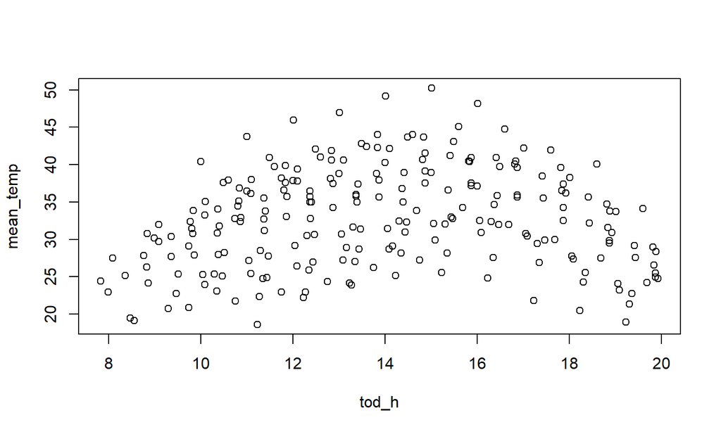

## Plot raw data for WEBL

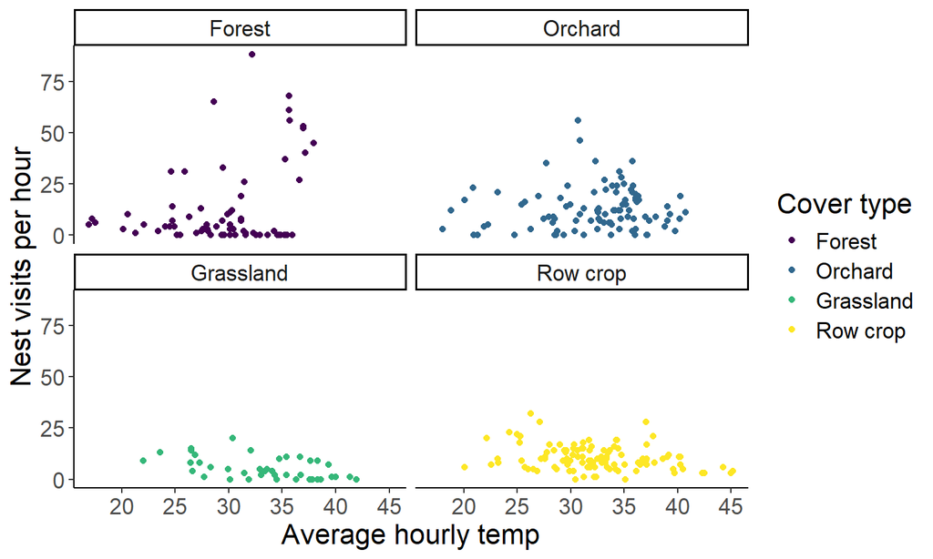

Looks like a lot of the outliers are in forest. Wondering if this could be caused by moving leaves being detected as birds??

## First task: Figure out what distribution to use for modeling these data.

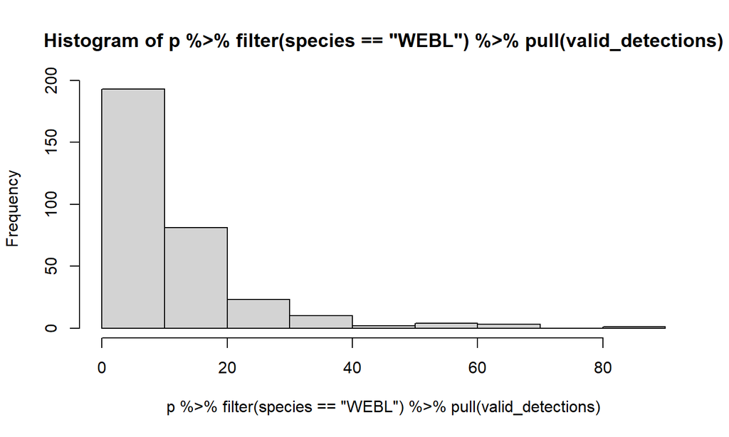

This looks like a poisson distribution would do okay here. But I will start with a Gaussian distribution for completeness.

## Base model with Gaussian distribution, qqplot

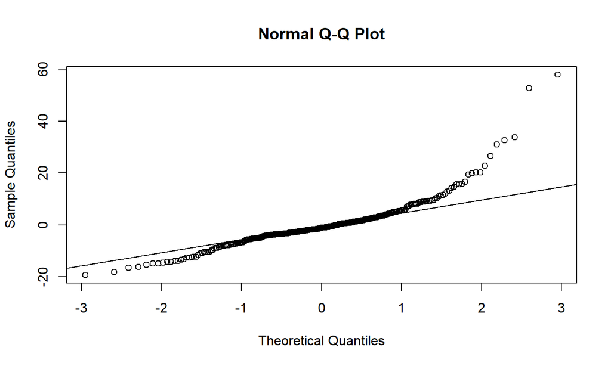

```
##        aic    bic r2.conditional r2.marginal       icc    rmse nobs
## 1 2272.722 2347.9      0.4159197   0.1938775 0.2754448 8.83681  317
```

## Base model with Poisson distribution, qqplot

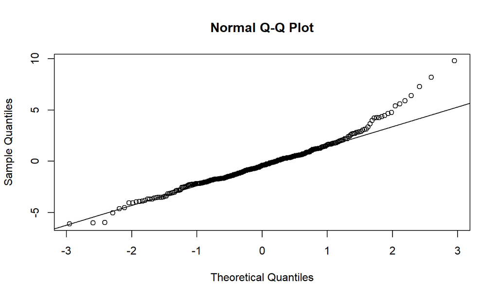

```
## # Check for Multicollinearity
##
## Low Correlation
##
##                      Term  VIF     VIF 95% CI Increased SE Tolerance
##                   habitat 1.18 [ 1.08,  1.39]         1.09      0.85
##        julian_date_scaled 3.23 [ 2.73,  3.87]         1.80      0.31
##  mean_nestling_age_scaled 3.04 [ 2.58,  3.64]         1.74      0.33
##     poly(tod_h_scaled, 2) 2.86 [ 2.43,  3.41]         1.69      0.35
##                  year_fct 1.19 [ 1.09,  1.40]         1.09      0.84
##  Tolerance 95% CI
##      [0.72, 0.92]
##      [0.26, 0.37]
##      [0.27, 0.39]
##      [0.29, 0.41]
##      [0.71, 0.92]
##
## High Correlation
##
##                               Term   VIF     VIF 95% CI Increased SE Tolerance
##          poly(mean_temp_scaled, 2) 17.47 [14.32, 21.37]         4.18      0.06
##  poly(mean_temp_scaled, 2):habitat 17.75 [14.55, 21.71]         4.21      0.06
##  Tolerance 95% CI
##      [0.05, 0.07]
##      [0.05, 0.07]
```

The Poisson distribution addresses the zero skewing but not the overdispersion?

## Test for overdispersion

```
##        aic      bic r2.conditional r2.marginal      icc     rmse nobs
## 1 2849.936 2921.355      0.8658983   0.3327908 0.799011 8.154948  317
```

```
## # Overdispersion test
##
##        dispersion ratio =    5.835
##   Pearson's Chi-Squared = 1738.790
##                 p-value =  < 0.001
```

```
## # Check for zero-inflation
##
##    Observed zeros: 40
##   Predicted zeros: 6
##             Ratio: 0.15
```

So, we do have overdispersion and zero inflation.

## Let’s try binomial distribution

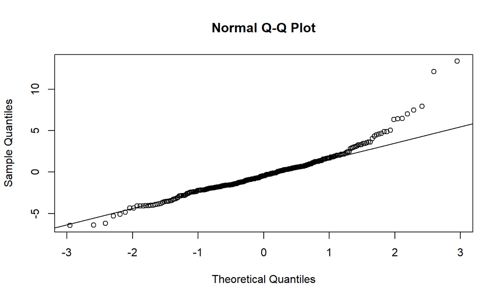

```
##        aic      bic r2.conditional r2.marginal       icc      rmse nobs
## 1 3229.778 3301.197      0.2036256  0.08140831 0.1330486 0.0928431  317
```

```
## # Overdispersion test
##
##  dispersion ratio = 2.296
##           p-value = 0.024
```

Dispersion ratio is smaller than for Poisson, but still doesn’t fully account for overdispersion.

## Negative binomial

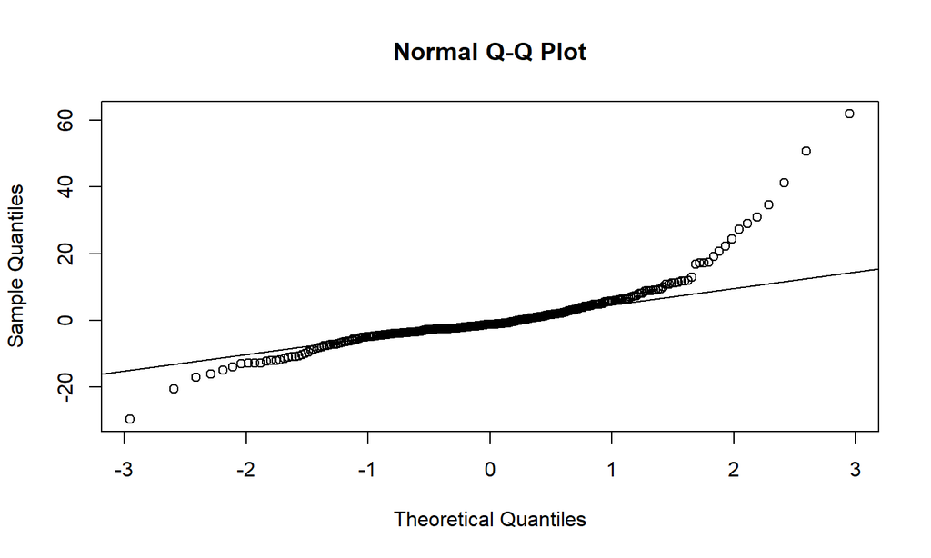

```
##       aic      bic r2.conditional r2.marginal       icc     rmse nobs
## 1 2105.11 2180.288      0.5446711   0.2263164 0.4114792 8.892014  317
```

```
## # Overdispersion test
##
##  dispersion ratio = 0.968
##           p-value = 0.784
```

```
## # Check for zero-inflation
##
##    Observed zeros: 40
##   Predicted zeros: 22
##             Ratio: 0.56
```

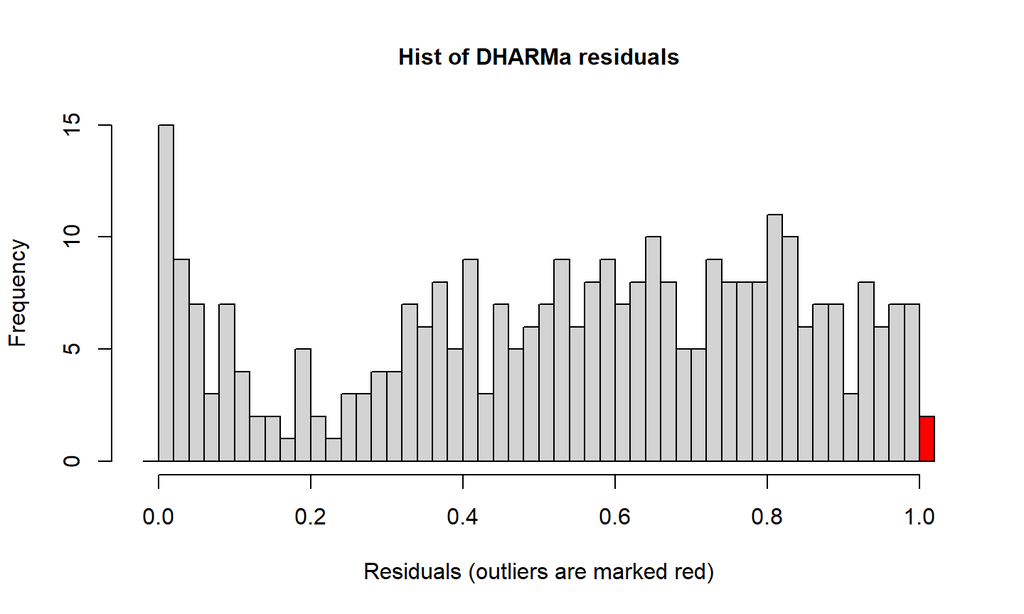

Negative binomial seems to address overdispersion and help with zeroinflation. If we add a zeroinflation term, what happens?

## Zero inflation model

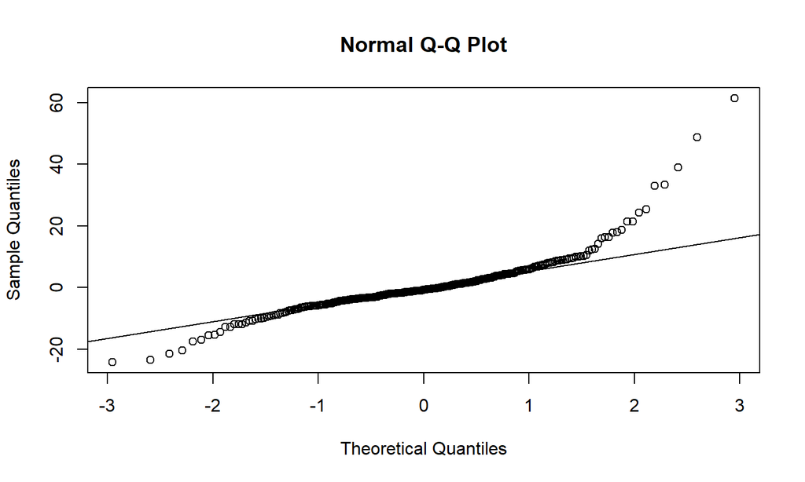

```
##        aic      bic r2.conditional r2.marginal       icc    rmse nobs
## 1 2081.786 2160.723      0.8043761   0.4964552 0.6115064 8.87989  317
```

```
## # Overdispersion test
##
##  dispersion ratio = 0.951
##           p-value = 0.752
```

```
## # Check for zero-inflation
##
##    Observed zeros: 40
##   Predicted zeros: 37
##             Ratio: 0.92
```

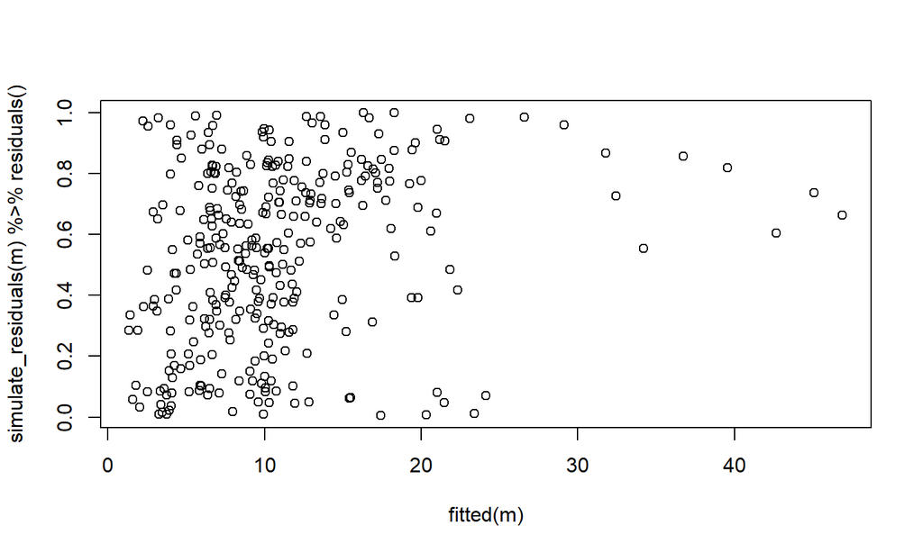

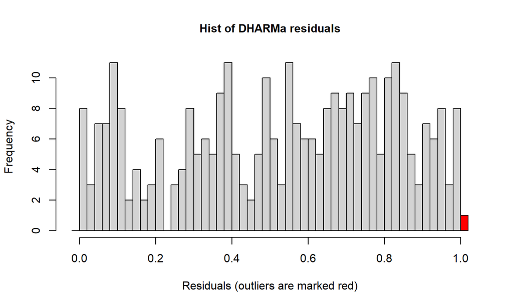

Test for overdispersion and zeroinflation are negative, but there appears to be some non-uniformity of residuals. Poisson instead of negative binomial results in more overdispersion.

Looks like there are some outliers. I wonder if we can justify clipping off outliers - does it make sense for birds to visit more than 60x/hour? I suspect some of those videos are from birds sitting in the entrance the whole time.

## Rows with > 60 visits/hour clipped.

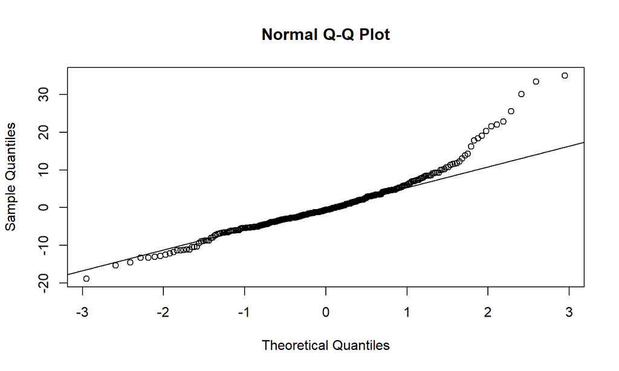

```
##        aic      bic r2.conditional r2.marginal       icc     rmse nobs
## 1 2019.842 2098.513      0.7377946   0.5384311 0.4319258 7.360379  313
```

```
## # Overdispersion test
##
##  dispersion ratio = 0.977
##           p-value = 0.912
```

```
## # Check for zero-inflation
##
##    Observed zeros: 40
##   Predicted zeros: 38
##             Ratio: 0.96
```

```
## OK: Simulated residuals appear as uniformly distributed (p = 0.078).
```

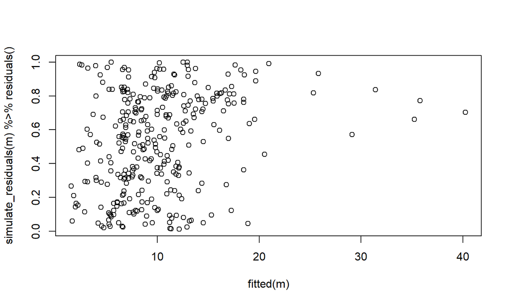

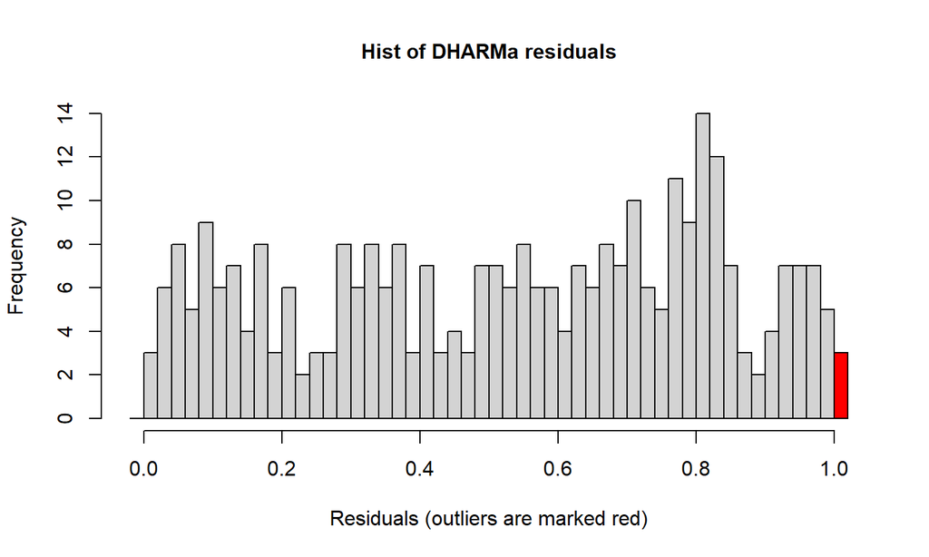

Still some funkiness, and fat tails. Still some non-uniformity.

## Provisioning ~ heat * habitat, WEBL, forest

Squared term is supported, but the weird thing is that the model outputs are all NaN for the squared model when the ziformula is ~ 1.

| model | Df | AIC | BIC | logLik | deviance | Chisq | Chi Df | Pr(>Chisq) |
| --- | --- | --- | --- | --- | --- | --- | --- | --- |
| no sq | 12 | 387.3320 | 413.4246 | -181.6660 | 363.3320 | NA | NA | NA |
| sq temp | 13 | 380.9099 | 409.1769 | -177.4549 | 354.9099 | 8.422091 | 1 | 0.003706892 |

```
##  Family: nbinom2  ( log )
## Formula:
## valid_detections ~ poly(mean_temp_scaled, 2, raw = TRUE) + julian_date_scaled +
##     mean_nestling_age_scaled + poly(tod_h_scaled, 2, raw = TRUE) +
##     (1 | attempt_id) + year_fct
## Zero inflation:                    ~poly(tod_h_scaled, 2, raw = TRUE)
## Data:
## dplyr::filter(p, habitat == "Forest", !is.na(mean_temp), !is.na(julian_date),
##     !is.na(mean_nestling_age), !is.na(tod_h), !is.na(site), !is.na(attempt_id),
##     !is.na(year), valid_detections < 60, species == "WEBL") %>%
##     mutate(across(c(tod_h, mean_temp, julian_date, mean_nestling_age),
##         ~scale(.x)[, 1], .names = "{.col}_scaled"))
##
##      AIC      BIC   logLik deviance df.resid
##    380.9    409.2   -177.5    354.9       52
##
## Random effects:
##
## Conditional model:
##  Groups     Name        Variance Std.Dev.
##  attempt_id (Intercept) 1.19e-09 3.45e-05
## Number of obs: 65, groups:  attempt_id, 6
##
## Dispersion parameter for nbinom2 family (): 1.57
##
## Conditional model:
##                                        Estimate Std. Error z value Pr(>|z|)
## (Intercept)                              2.9213     0.3691   7.916 2.46e-15 ***
## poly(mean_temp_scaled, 2, raw = TRUE)1  -0.6884     0.5218  -1.319 0.187086
## poly(mean_temp_scaled, 2, raw = TRUE)2   0.3175     0.1078   2.946 0.003215 **
## julian_date_scaled                      -1.0413     0.2673  -3.896 9.80e-05 ***
## mean_nestling_age_scaled                 1.2316     0.4244   2.902 0.003706 **
## poly(tod_h_scaled, 2, raw = TRUE)1      -0.6370     0.1863  -3.419 0.000628 ***
## poly(tod_h_scaled, 2, raw = TRUE)2      -0.7935     0.3128  -2.537 0.011190 *
## year_fct2023                            -1.6871     0.5085  -3.318 0.000908 ***
## ---
## Signif. codes:  0 '***' 0.001 '**' 0.01 '*' 0.05 '.' 0.1 ' ' 1
##
## Zero-inflation model:
##                                    Estimate Std. Error z value Pr(>|z|)
## (Intercept)                          -1.818      1.051  -1.730   0.0836 .
## poly(tod_h_scaled, 2, raw = TRUE)1    2.048      1.852   1.106   0.2689
## poly(tod_h_scaled, 2, raw = TRUE)2   -1.664      2.379  -0.699   0.4844
## ---
## Signif. codes:  0 '***' 0.001 '**' 0.01 '*' 0.05 '.' 0.1 ' ' 1
```

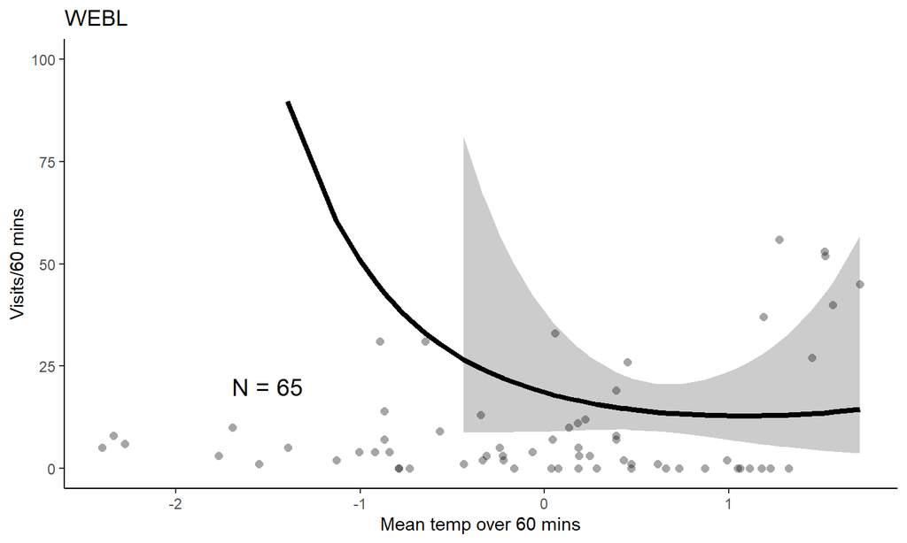

This doesn’t seem to fit particularly well… How about the no sq model?

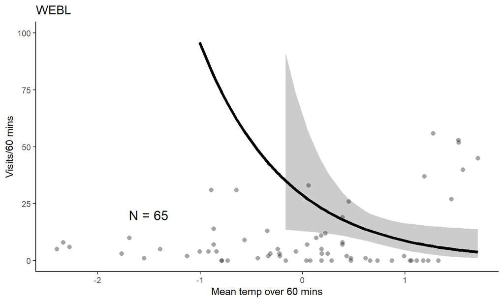

Also not great.

## Provisioning ~ heat * habitat, WEBL, orchard

Squared term not supported

| model | Df | AIC | BIC | logLik | deviance | Chisq | Chi Df | Pr(>Chisq) |
| --- | --- | --- | --- | --- | --- | --- | --- | --- |
| no sq | 11 | 657.3587 | 685.6806 | -317.6794 | 635.3587 | NA | NA | NA |
| sq max temp | 12 | 659.2726 | 690.1691 | -317.6363 | 635.2726 | 0.08613663 | 1 | 0.7691473 |

```
##  Family: nbinom2  ( log )
## Formula:
## valid_detections ~ mean_temp_scaled + julian_date_scaled + mean_nestling_age_scaled +
##     poly(tod_h_scaled, 2, raw = TRUE) + (1 | attempt_id) + year_fct
## Zero inflation:                    ~1
## Data:
## dplyr::filter(p, habitat == "Orchard", !is.na(mean_temp), !is.na(julian_date),
##     !is.na(mean_nestling_age), !is.na(tod_h), !is.na(site), !is.na(attempt_id),
##     !is.na(year), species == "WEBL") %>% mutate(across(c(tod_h,
##     mean_temp, julian_date, mean_nestling_age), ~scale(.x)[,
##     1], .names = "{.col}_scaled"))
##
##      AIC      BIC   logLik deviance df.resid
##    657.4    685.7   -317.7    635.4       86
##
## Random effects:
##
## Conditional model:
##  Groups     Name        Variance Std.Dev.
##  attempt_id (Intercept) 0.1813   0.4258
## Number of obs: 97, groups:  attempt_id, 11
##
## Dispersion parameter for nbinom2 family (): 4.13
##
## Conditional model:
##                                    Estimate Std. Error z value Pr(>|z|)
## (Intercept)                         1.83558    0.49461   3.711 0.000206 ***
## mean_temp_scaled                    0.28524    0.15098   1.889 0.058865 .
## julian_date_scaled                 -0.34645    0.19093  -1.814 0.069602 .
## mean_nestling_age_scaled            0.29794    0.08786   3.391 0.000696 ***
## poly(tod_h_scaled, 2, raw = TRUE)1 -0.06184    0.09582  -0.645 0.518667
## poly(tod_h_scaled, 2, raw = TRUE)2  0.32779    0.10320   3.176 0.001492 **
## year_fct2022                       -0.26068    0.52459  -0.497 0.619249
## year_fct2023                        0.46027    0.54282   0.848 0.396485
## ---
## Signif. codes:  0 '***' 0.001 '**' 0.01 '*' 0.05 '.' 0.1 ' ' 1
##
## Zero-inflation model:
##             Estimate Std. Error z value Pr(>|z|)
## (Intercept)  -3.0397     0.7357  -4.132  3.6e-05 ***
## ---
## Signif. codes:  0 '***' 0.001 '**' 0.01 '*' 0.05 '.' 0.1 ' ' 1
```

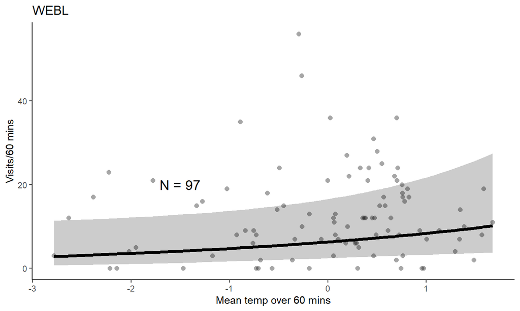

This fits a lot better.

## Provisioning ~ heat * habitat, WEBL, grassland

Squared term not supported

| model | Df | AIC | BIC | logLik | deviance | Chisq | Chi Df | Pr(>Chisq) |
| --- | --- | --- | --- | --- | --- | --- | --- | --- |
| no sq | 11 | 214.3595 | 232.9372 | -96.17975 | 192.3595 | NA | NA | NA |
| sq max temp | 12 | 214.7525 | 235.0191 | -95.37625 | 190.7525 | 1.606997 | 1 | 0.2049145 |

```
##  Family: nbinom2  ( log )
## Formula:
## valid_detections ~ mean_temp_scaled + julian_date_scaled + mean_nestling_age_scaled +
##     poly(tod_h_scaled, 2, raw = TRUE) + (1 | attempt_id) + year_fct
## Zero inflation:                    ~1
## Data:
## dplyr::filter(p, habitat == "Grassland", !is.na(mean_temp), !is.na(julian_date),
##     !is.na(mean_nestling_age), !is.na(tod_h), !is.na(site), !is.na(attempt_id),
##     !is.na(year), species == "WEBL") %>% mutate(across(c(tod_h,
##     mean_temp, julian_date, mean_nestling_age), ~scale(.x)[,
##     1], .names = "{.col}_scaled"))
##
##      AIC      BIC   logLik deviance df.resid
##    214.4    232.9    -96.2    192.4       29
##
## Random effects:
##
## Conditional model:
##  Groups     Name        Variance  Std.Dev.
##  attempt_id (Intercept) 4.704e-14 2.169e-07
## Number of obs: 40, groups:  attempt_id, 5
##
## Dispersion parameter for nbinom2 family (): 2.49
##
## Conditional model:
##                                     Estimate Std. Error z value Pr(>|z|)
## (Intercept)                         0.000529   0.738803   0.001  0.99943
## mean_temp_scaled                    0.958342   0.610094   1.571  0.11623
## julian_date_scaled                 -1.449380   0.583464  -2.484  0.01299 *
## mean_nestling_age_scaled            0.350660   0.259935   1.349  0.17733
## poly(tod_h_scaled, 2, raw = TRUE)1 -0.510042   0.222919  -2.288  0.02214 *
## poly(tod_h_scaled, 2, raw = TRUE)2  2.046793   0.712273   2.874  0.00406 **
## year_fct2022                       -0.388401   0.740263  -0.525  0.59981
## year_fct2023                       -1.649684   1.207200  -1.366  0.17177
## ---
## Signif. codes:  0 '***' 0.001 '**' 0.01 '*' 0.05 '.' 0.1 ' ' 1
##
## Zero-inflation model:
##             Estimate Std. Error z value Pr(>|z|)
## (Intercept)   -21.04   11204.94  -0.002    0.999
```

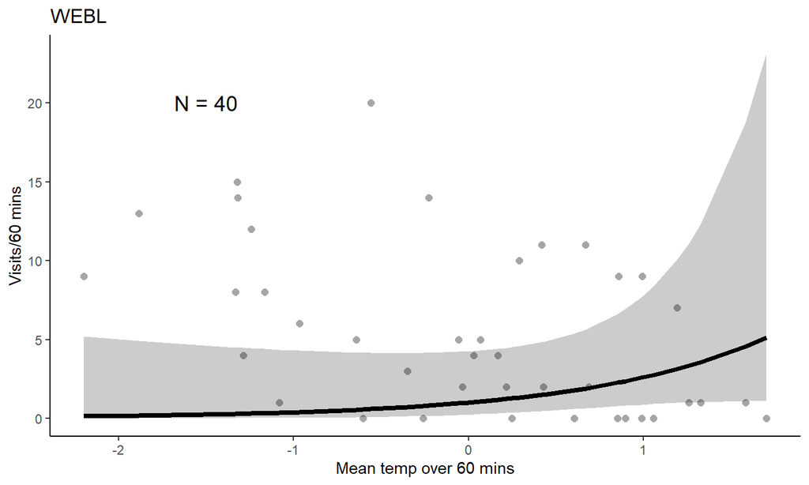

This also does not fit very well…

## Provisioning ~ heat * habitat, WEBL, row crop

Squared term is not supported.

| model | Df | AIC | BIC | logLik | deviance | Chisq | Chi Df | Pr(>Chisq) |
| --- | --- | --- | --- | --- | --- | --- | --- | --- |
| no sq | 10 | 682.6396 | 709.7349 | -331.3198 | 662.6396 | NA | NA | NA |
| sq max temp | 11 | 684.1120 | 713.9168 | -331.0560 | 662.1120 | 0.5276167 | 1 | 0.4676106 |

```
##  Family: nbinom2  ( log )
## Formula:
## valid_detections ~ poly(mean_temp_scaled, 2, raw = TRUE) + julian_date_scaled +
##     mean_nestling_age_scaled + poly(tod_h_scaled, 2, raw = TRUE) +
##     (1 | attempt_id) + year_fct
## Zero inflation:                    ~1
## Data:
## dplyr::filter(p, habitat == "Row crop", !is.na(mean_temp), !is.na(julian_date),
##     !is.na(mean_nestling_age), !is.na(tod_h), !is.na(site), !is.na(attempt_id),
##     !is.na(year), species == "WEBL") %>% mutate(across(c(tod_h,
##     mean_temp, julian_date, mean_nestling_age), ~scale(.x)[,
##     1], .names = "{.col}_scaled"))
##
##      AIC      BIC   logLik deviance df.resid
##    684.1    713.9   -331.1    662.1      100
##
## Random effects:
##
## Conditional model:
##  Groups     Name        Variance  Std.Dev.
##  attempt_id (Intercept) 2.719e-10 1.649e-05
## Number of obs: 111, groups:  attempt_id, 7
##
## Dispersion parameter for nbinom2 family ():  8.1
##
## Conditional model:
##                                         Estimate Std. Error z value Pr(>|z|)
## (Intercept)                             2.490360   0.090156  27.623  < 2e-16
## poly(mean_temp_scaled, 2, raw = TRUE)1 -0.206392   0.075529  -2.733  0.00628
## poly(mean_temp_scaled, 2, raw = TRUE)2 -0.029754   0.040910  -0.727  0.46704
## julian_date_scaled                      0.190013   0.066278   2.867  0.00414
## mean_nestling_age_scaled               -0.011115   0.055555  -0.200  0.84142
## poly(tod_h_scaled, 2, raw = TRUE)1      0.052118   0.045927   1.135  0.25646
## poly(tod_h_scaled, 2, raw = TRUE)2     -0.004723   0.078889  -0.060  0.95226
## year_fct2023                           -0.306937   0.098279  -3.123  0.00179
##
## (Intercept)                            ***
## poly(mean_temp_scaled, 2, raw = TRUE)1 **
## poly(mean_temp_scaled, 2, raw = TRUE)2
## julian_date_scaled                     **
## mean_nestling_age_scaled
## poly(tod_h_scaled, 2, raw = TRUE)1
## poly(tod_h_scaled, 2, raw = TRUE)2
## year_fct2023                           **
## ---
## Signif. codes:  0 '***' 0.001 '**' 0.01 '*' 0.05 '.' 0.1 ' ' 1
##
## Zero-inflation model:
##             Estimate Std. Error z value Pr(>|z|)
## (Intercept)  -4.0604     0.7608  -5.337 9.46e-08 ***
## ---
## Signif. codes:  0 '***' 0.001 '**' 0.01 '*' 0.05 '.' 0.1 ' ' 1
```

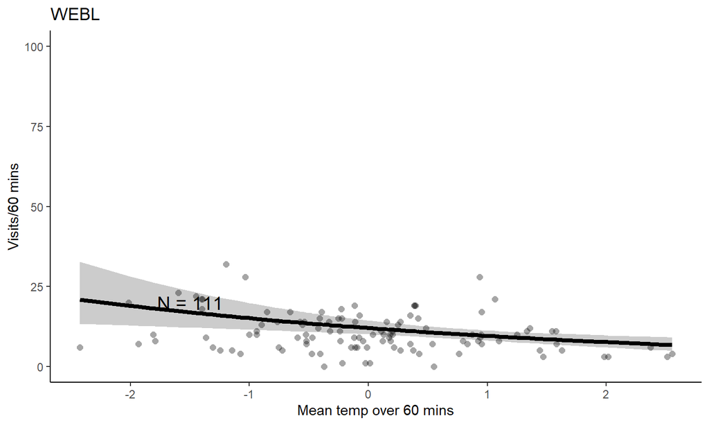

## Conclusions

Squared temp is important in forest, but the model doesn’t fit great. I’m leaning no squared temp term, personally.

| Habitat | Sq temp |
| --- | --- |
| Forest | * |
| Orchard |  |
| Grassland |  |
| Row crop |  |

## Is the squared term supported in the overall model?

| model | Df | AIC | BIC | logLik | deviance | Chisq | Chi Df | Pr(>Chisq) |
| --- | --- | --- | --- | --- | --- | --- | --- | --- |
| no sq | 17 | 2024.387 | 2088.072 | -995.1935 | 1990.387 | NA | NA | NA |
| linear temp interaction | 18 | 2026.352 | 2093.784 | -995.1760 | 1990.352 | 0.03500153 | 1 | 0.85159246 |
| sq max temp | 21 | 2019.842 | 2098.513 | -988.9212 | 1977.842 | 12.50955964 | 3 | 0.00582669 |

## Plotting inference model

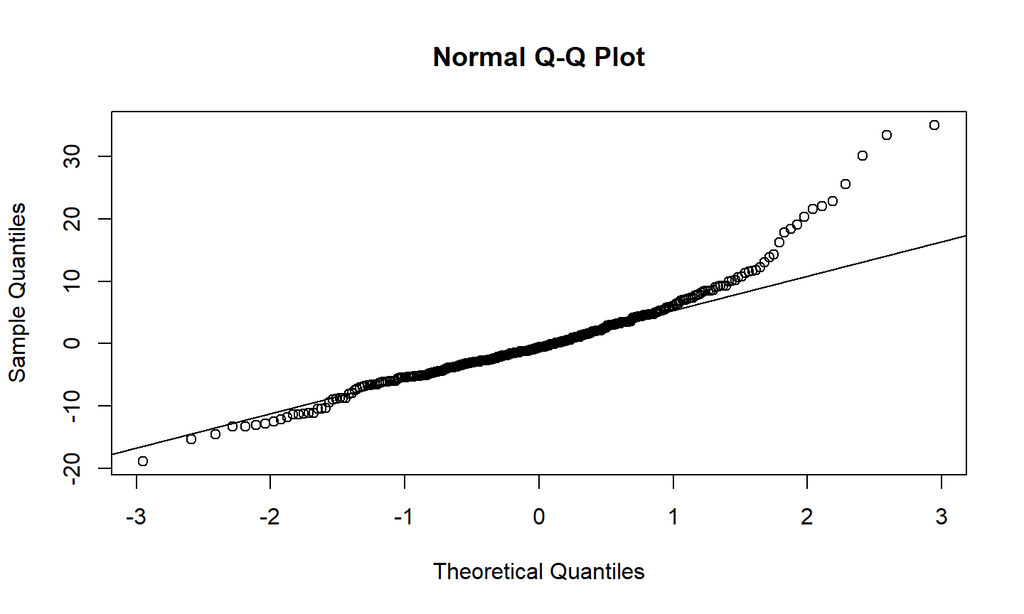

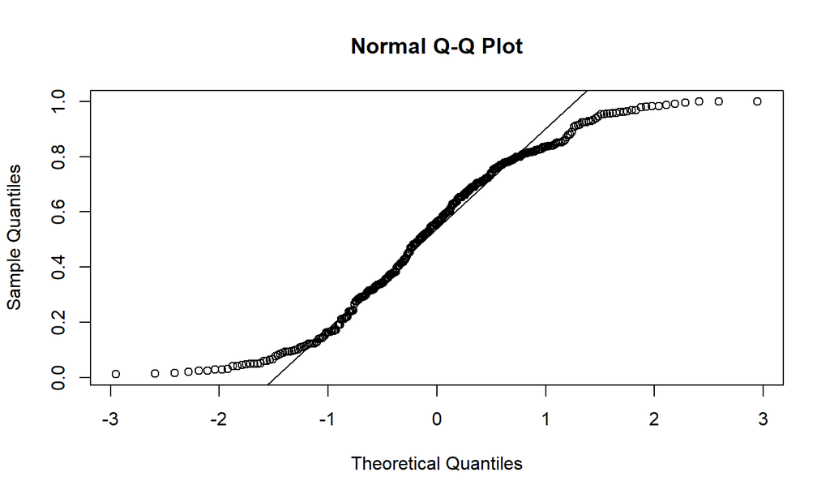

```
##        aic      bic r2.conditional r2.marginal       icc     rmse nobs
## 1 2019.842 2098.513      0.7377946   0.5384311 0.4319258 7.360379  313
```

```
## # Overdispersion test
##
##  dispersion ratio = 0.977
##           p-value = 0.912
```

```
## # Check for zero-inflation
##
##    Observed zeros: 40
##   Predicted zeros: 38
##             Ratio: 0.96
```

```
## OK: Simulated residuals appear as uniformly distributed (p = 0.078).
```

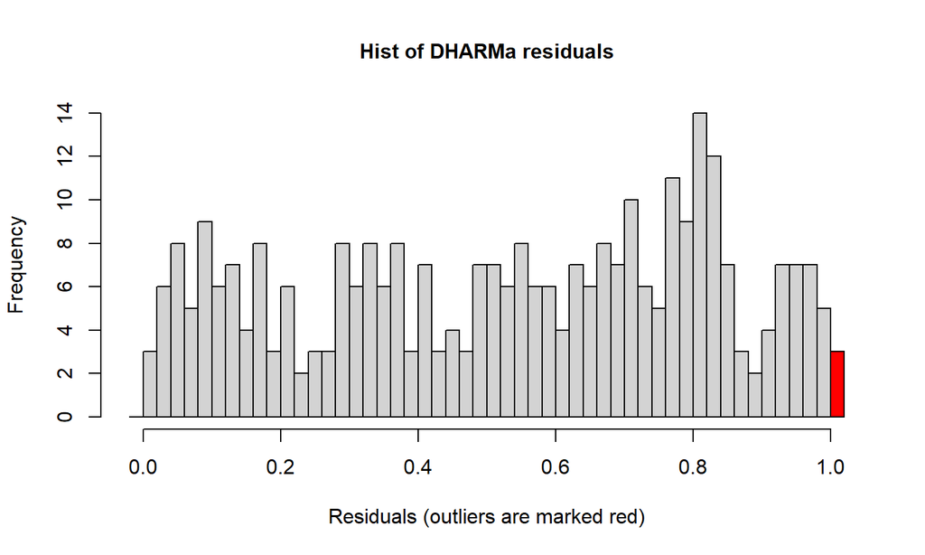

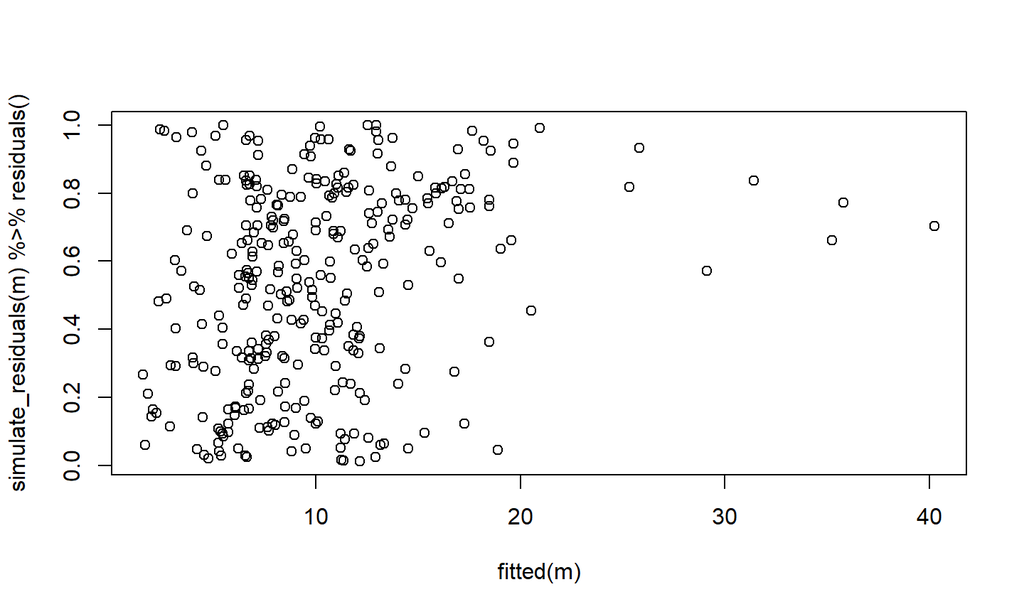

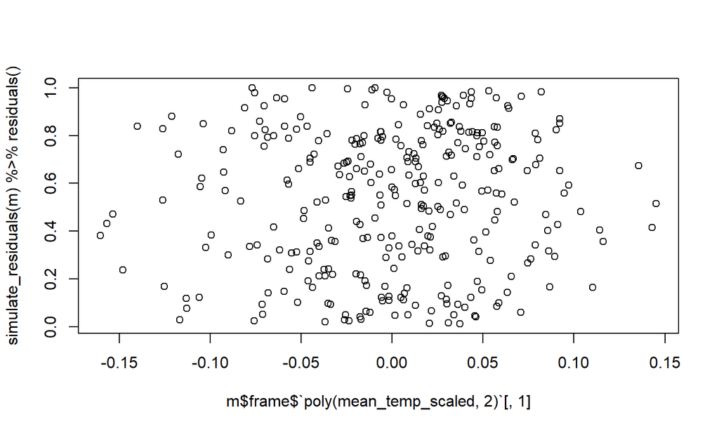

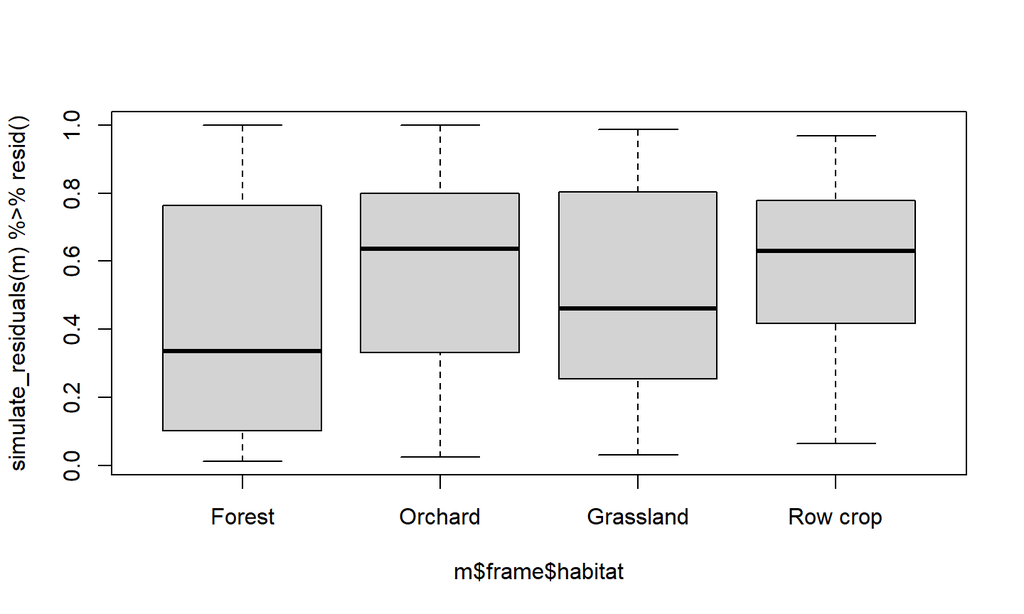

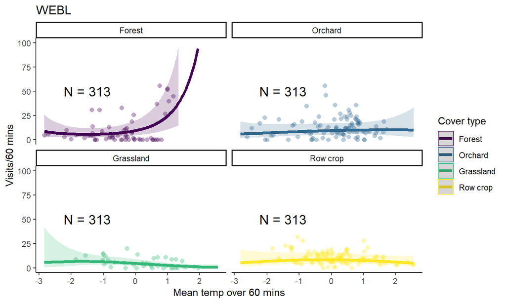

```
##  Family: nbinom2  ( log )
## Formula:
## valid_detections ~ poly(mean_temp_scaled, 2) * habitat + julian_date_scaled +
##     mean_nestling_age_scaled + poly(tod_h_scaled, 2) + (1 | attempt_id) +
##     year_fct
## Zero inflation:                    ~1
## Data:
## dplyr::filter(p, !is.na(mean_temp), !is.na(julian_date), !is.na(mean_nestling_age),
##     !is.na(tod_h), !is.na(site), !is.na(attempt_id), !is.na(year),
##     valid_detections < 60, species == "WEBL") %>% mutate(across(c(tod_h,
##     mean_temp, julian_date, mean_nestling_age), ~scale(.x)[,
##     1], .names = "{.col}_scaled"))
##
##      AIC      BIC   logLik deviance df.resid
##   2019.8   2098.5   -988.9   1977.8      292
##
## Random effects:
##
## Conditional model:
##  Groups     Name        Variance Std.Dev.
##  attempt_id (Intercept) 0.08165  0.2857
## Number of obs: 313, groups:  attempt_id, 29
##
## Dispersion parameter for nbinom2 family (): 3.64
##
## Conditional model:
##                                              Estimate Std. Error z value
## (Intercept)                                   2.61163    0.37275   7.006
## poly(mean_temp_scaled, 2)1                   11.21825    2.50135   4.485
## poly(mean_temp_scaled, 2)2                    5.89664    1.89786   3.107
## habitatOrchard                               -0.26796    0.24904  -1.076
## habitatGrassland                             -1.10499    0.29857  -3.701
## habitatRow crop                              -0.43335    0.25479  -1.701
## julian_date_scaled                           -0.07454    0.08747  -0.852
## mean_nestling_age_scaled                      0.17788    0.05232   3.400
## poly(tod_h_scaled, 2)1                       -0.11957    0.72902  -0.164
## poly(tod_h_scaled, 2)2                        2.29691    1.22202   1.880
## year_fct2022                                  0.14563    0.30237   0.482
## year_fct2023                                  0.01583    0.29240   0.054
## poly(mean_temp_scaled, 2)1:habitatOrchard    -9.48977    2.91894  -3.251
```

[output cut: 17 more lines]

```
## year_fct2023                                0.956814
## poly(mean_temp_scaled, 2)1:habitatOrchard   0.001150 **
## poly(mean_temp_scaled, 2)2:habitatOrchard   0.008399 **
## poly(mean_temp_scaled, 2)1:habitatGrassland 1.21e-07 ***
## poly(mean_temp_scaled, 2)2:habitatGrassland 0.014576 *
## poly(mean_temp_scaled, 2)1:habitatRow crop  6.05e-05 ***
## poly(mean_temp_scaled, 2)2:habitatRow crop  0.001120 **
## ---
## Signif. codes:  0 '***' 0.001 '**' 0.01 '*' 0.05 '.' 0.1 ' ' 1
##
## Zero-inflation model:
##             Estimate Std. Error z value Pr(>|z|)
## (Intercept)  -2.1846     0.2291  -9.535   <2e-16 ***
## ---
## Signif. codes:  0 '***' 0.001 '**' 0.01 '*' 0.05 '.' 0.1 ' ' 1
```

## Provis by time of day: TRES, 1h

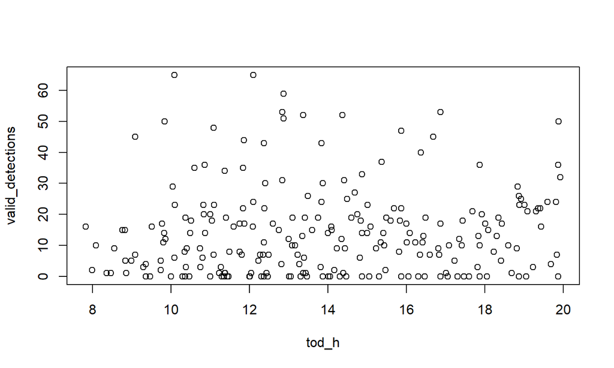

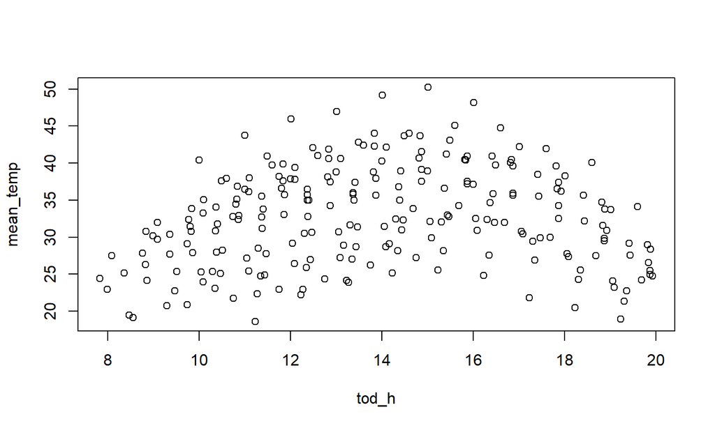

So now provisioning and temp actually both line up in a way that seems reasonable. Yay!

## Plot raw data for TRES

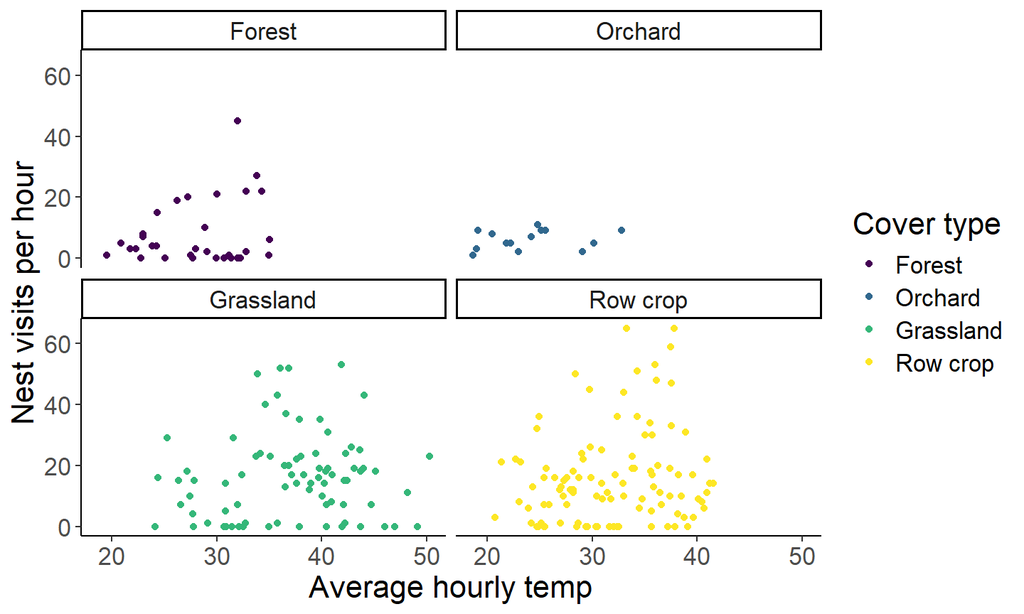

Looks like way higher average detection for TRES. I’m a little worried that TRES data is inflated because they are much more likely to sit in the hole of the nest. I think I would have to build another classification model to identify those videos, though it would certainly be possible.

## First task: Figure out what distribution to use for modeling these data.

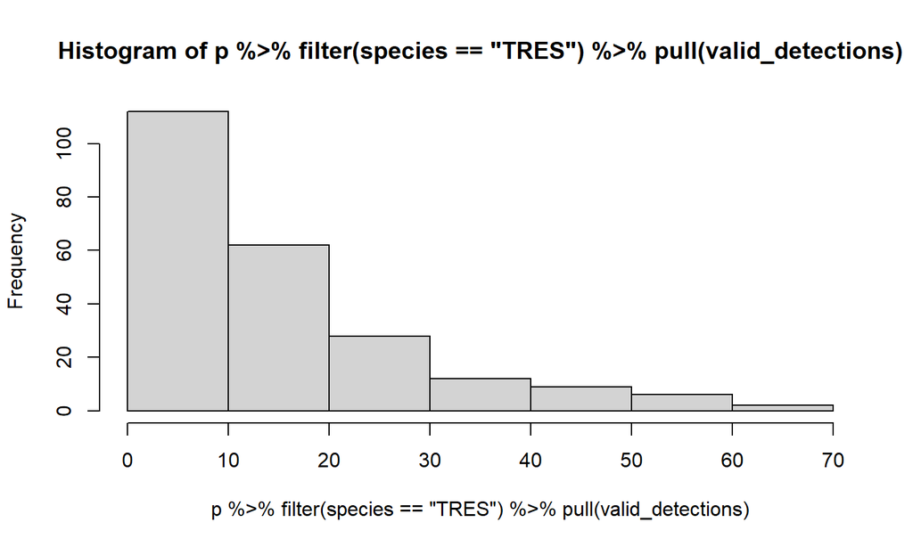

This looks like a Poisson distribution would be overdispersed. But I’ll run through all of the other distributions for completeness.

## Base model with Gaussian distribution, qqplot

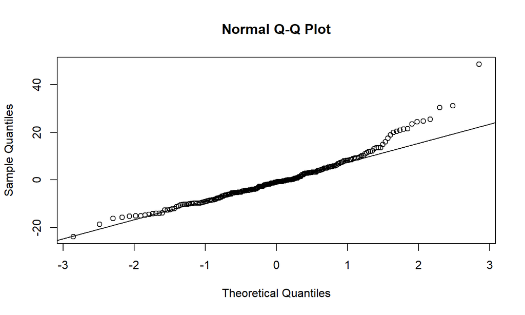

```
##        aic      bic r2.conditional r2.marginal       icc     rmse nobs
## 1 1685.204 1754.052      0.5994185   0.1466814 0.5305605 9.665703  231
```

## Base model with Poisson distribution, qqplot

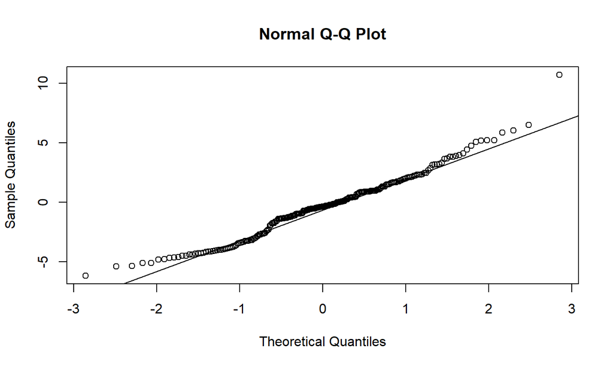

```
## # Check for Multicollinearity
##
## Low Correlation
##
##                      Term  VIF         VIF 95% CI Increased SE Tolerance
##                   habitat 3.57 [   2.94,    4.41]         1.89      0.28
##  mean_nestling_age_scaled 4.95 [   4.03,    6.15]         2.22      0.20
##     poly(tod_h_scaled, 2) 3.45 [   2.85,    4.25]         1.86      0.29
##                  year_fct 2.06 [   1.75,    2.50]         1.43      0.49
##  Tolerance 95% CI
##      [0.23, 0.34]
##      [0.16, 0.25]
##      [0.24, 0.35]
##      [0.40, 0.57]
##
## Moderate Correlation
##
##                Term  VIF         VIF 95% CI Increased SE Tolerance
##  julian_date_scaled 5.40 [   4.38,    6.71]         2.32      0.19
##  Tolerance 95% CI
##      [0.15, 0.23]
##
## High Correlation
##
##                               Term     VIF         VIF 95% CI Increased SE
##          poly(mean_temp_scaled, 2) 2838.50 [2243.75, 3590.97]        53.28
##  poly(mean_temp_scaled, 2):habitat 6164.64 [4872.83, 7798.98]        78.52
##  Tolerance Tolerance 95% CI
##   3.52e-04     [0.00, 0.00]
##   1.62e-04     [0.00, 0.00]
```

## Test for overdispersion

```
##       aic      bic r2.conditional r2.marginal      icc     rmse nobs
## 1 2633.47 2698.876      0.9616209   0.4911621 0.924575 9.348511  231
```

```
## # Overdispersion test
##
##        dispersion ratio =    7.820
##   Pearson's Chi-Squared = 1657.933
##                 p-value =  < 0.001
```

```
## # Check for zero-inflation
##
##    Observed zeros: 42
##   Predicted zeros: 7
##             Ratio: 0.17
```

So, we do have overdispersion and zero inflation.

## Let’s try binomial distribution

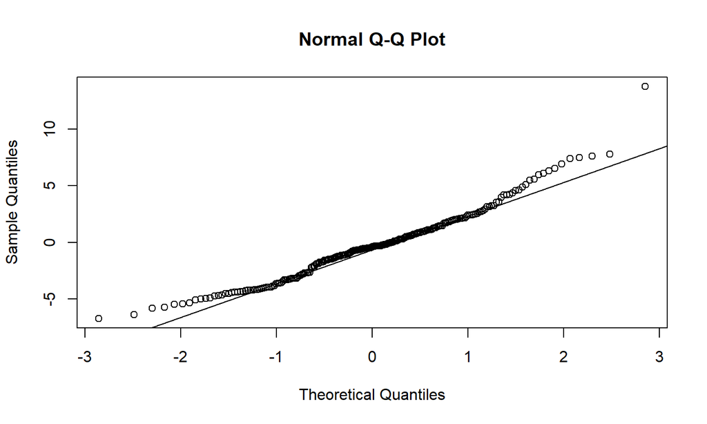

```
##        aic      bic r2.conditional r2.marginal      icc      rmse nobs
## 1 3121.358 3186.764      0.4585998   0.2336588 0.293526 0.1436397  231
```

```
## # Overdispersion test
##
##  dispersion ratio = 0.771
##           p-value =   0.4
```

Dispersion ratio is accounted for, but model doesn’t converge- probably the zero inflation.

## Negative binomial

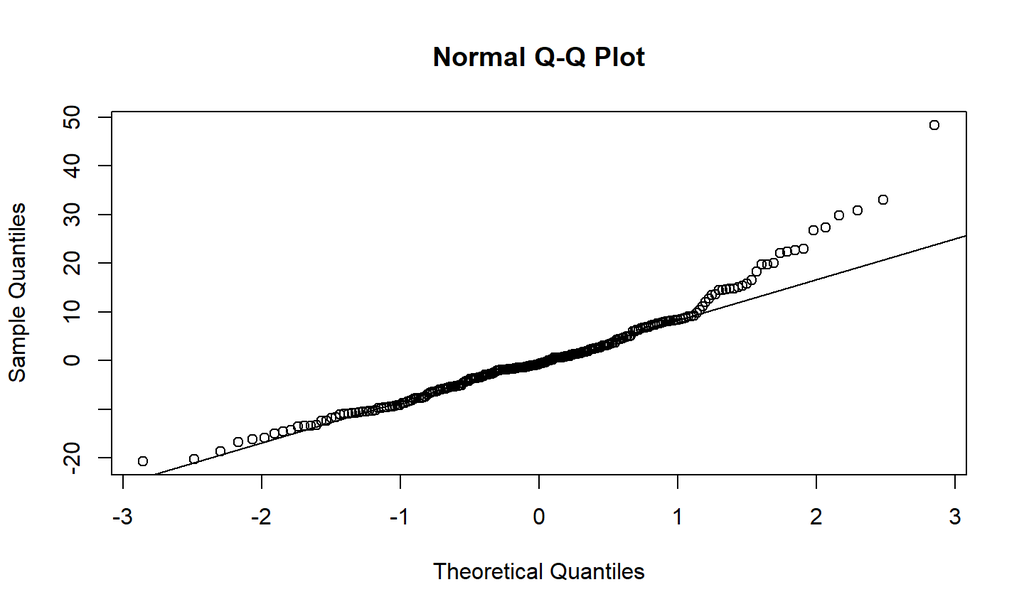

```
##       aic      bic r2.conditional r2.marginal       icc     rmse nobs
## 1 1683.83 1752.679      0.5034279   0.2410555 0.3457069 9.985896  231
```

```
## # Overdispersion test
##
##  dispersion ratio = 0.325
##           p-value = 0.048
```

```
## # Check for zero-inflation
##
##    Observed zeros: 42
##   Predicted zeros: 22
##             Ratio: 0.52
```

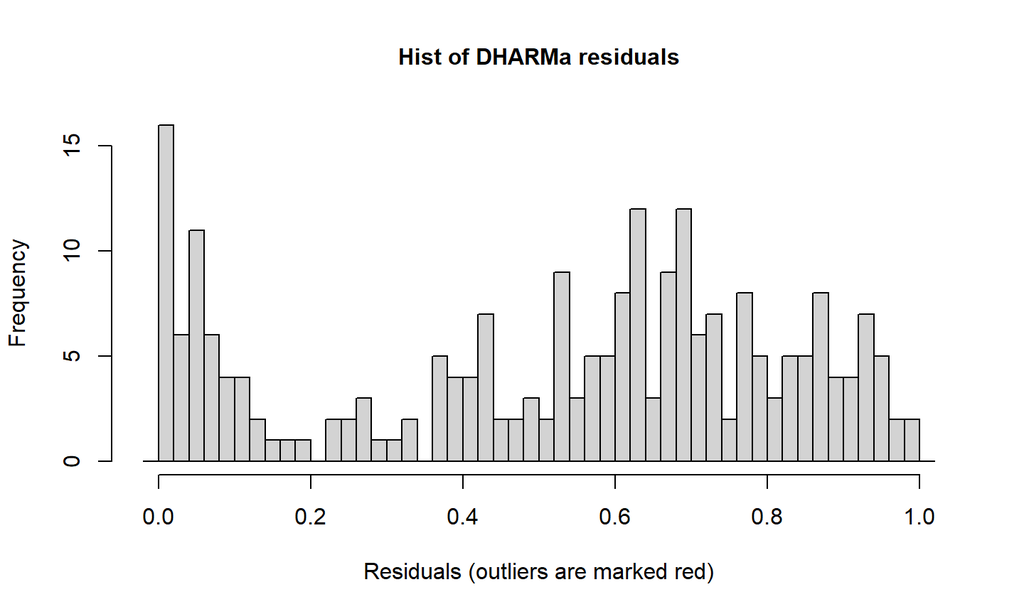

Negative binomial seems to address overdispersion and help with zeroinflation. If we add a zeroinflation term, what happens?

## Zero inflation model (~1)

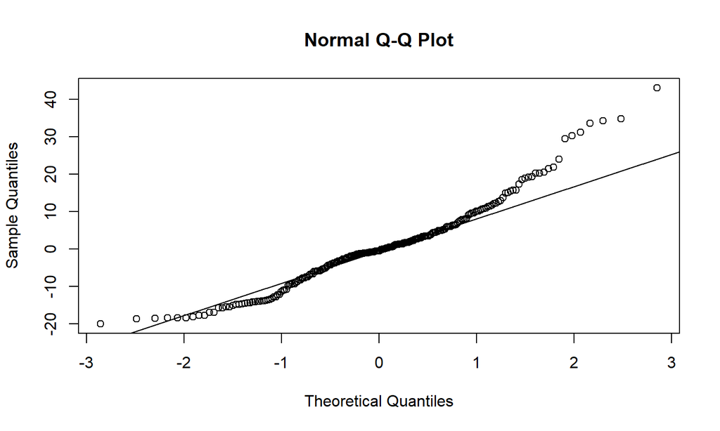

```
##        aic      bic r2.conditional r2.marginal       icc     rmse nobs
## 1 1616.703 1688.994      0.8790488   0.6515396 0.6528983 11.06691  231
```

```
## # Overdispersion test
##
##  dispersion ratio = 0.879
##           p-value = 0.712
```

```
## # Check for zero-inflation
##
##    Observed zeros: 42
##   Predicted zeros: 43
##             Ratio: 1.03
```

```
## OK: Simulated residuals appear as uniformly distributed (p = 0.577).
```

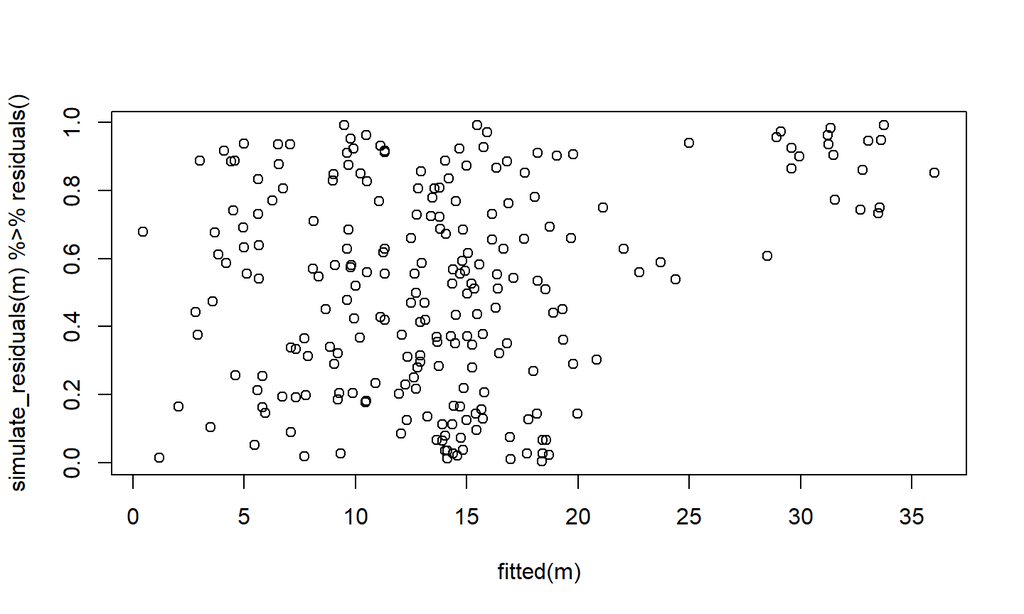

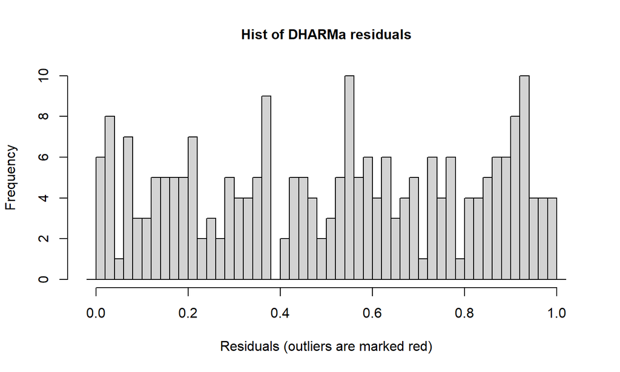

Test for overdispersion and zeroinflation are negative, and residuals seem uniformly distributed. Are we good to go?

## Provisioning ~ heat * habitat, TRES, forest

Squared term is not supported.

| model | Df | AIC | BIC | logLik | deviance | Chisq | Chi Df | Pr(>Chisq) |
| --- | --- | --- | --- | --- | --- | --- | --- | --- |
| no sq | 11 | 188.4879 | 204.6110 | -83.24394 | 166.4879 | NA | NA | NA |
| sq temp | 12 | 188.2787 | 205.8675 | -82.13933 | 164.2787 | 2.20922 | 1 | 0.137188 |

```
##  Family: nbinom2  ( log )
## Formula:
## valid_detections ~ poly(mean_temp_scaled, 2, raw = TRUE) + julian_date_scaled +
##     mean_nestling_age_scaled + poly(tod_h_scaled, 2, raw = TRUE) +
##     (1 | attempt_id) + year_fct
## Zero inflation:                    ~1
## Data:
## dplyr::filter(p, habitat == "Forest", !is.na(mean_temp), !is.na(julian_date),
##     !is.na(mean_nestling_age), !is.na(tod_h), !is.na(site), !is.na(attempt_id),
##     !is.na(year), species == "TRES") %>% mutate(across(c(tod_h,
##     mean_temp, julian_date, mean_nestling_age), ~scale(.x)[,
##     1], .names = "{.col}_scaled"))
##
##      AIC      BIC   logLik deviance df.resid
##    188.3    205.9    -82.1    164.3       20
##
## Random effects:
##
## Conditional model:
##  Groups     Name        Variance  Std.Dev.
##  attempt_id (Intercept) 1.478e-15 3.845e-08
## Number of obs: 32, groups:  attempt_id, 5
##
## Dispersion parameter for nbinom2 family ():  1.4
##
## Conditional model:
##                                        Estimate Std. Error z value Pr(>|z|)
## (Intercept)                              1.3307     0.8021   1.659 0.097092 .
## poly(mean_temp_scaled, 2, raw = TRUE)1  -2.4069     1.3011  -1.850 0.064323 .
## poly(mean_temp_scaled, 2, raw = TRUE)2   0.6284     0.3367   1.867 0.061970 .
## julian_date_scaled                       1.1005     0.8602   1.279 0.200775
## mean_nestling_age_scaled                -1.5808     0.4340  -3.642 0.000271 ***
## poly(tod_h_scaled, 2, raw = TRUE)1       1.7419     0.6731   2.588 0.009658 **
## poly(tod_h_scaled, 2, raw = TRUE)2      -1.8544     0.7786  -2.382 0.017240 *
## year_fct2022                             2.3994     1.1127   2.156 0.031057 *
## year_fct2023                             1.1074     0.8544   1.296 0.194960
## ---
## Signif. codes:  0 '***' 0.001 '**' 0.01 '*' 0.05 '.' 0.1 ' ' 1
##
## Zero-inflation model:
##             Estimate Std. Error z value Pr(>|z|)
## (Intercept)   -21.15    9548.96  -0.002    0.998
```

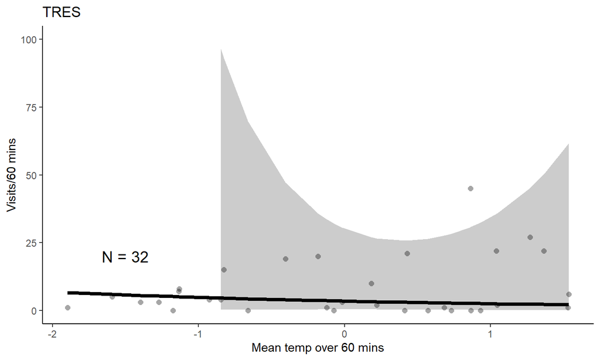

This seems okay, but the errors are huge.

## Provisioning ~ heat * habitat, TRES, orchard

Squared term not supported

| model | Df | AIC | BIC | logLik | deviance | Chisq | Chi Df | Pr(>Chisq) |
| --- | --- | --- | --- | --- | --- | --- | --- | --- |
| no sq | 9 | 72.02034 | 77.77185 | -27.01017 | 54.02034 | NA | NA | NA |
| sq max temp | 10 | 74.00973 | 80.40030 | -27.00486 | 54.00973 | 0.01061021 | 1 | 0.9179583 |

```
##  Family: nbinom2  ( log )
## Formula:
## valid_detections ~ mean_temp_scaled + julian_date_scaled + mean_nestling_age_scaled +
##     poly(tod_h_scaled, 2, raw = TRUE) + (1 | attempt_id)
## Zero inflation:                    ~1
## Data:
## dplyr::filter(p, habitat == "Orchard", !is.na(mean_temp), !is.na(julian_date),
##     !is.na(mean_nestling_age), !is.na(tod_h), !is.na(site), !is.na(attempt_id),
##     !is.na(year), species == "TRES") %>% mutate(across(c(tod_h,
##     mean_temp, julian_date, mean_nestling_age), ~scale(.x)[,
##     1], .names = "{.col}_scaled"))
##
##      AIC      BIC   logLik deviance df.resid
##     72.0     77.8    -27.0     54.0        5
##
## Random effects:
##
## Conditional model:
##  Groups     Name        Variance  Std.Dev.
##  attempt_id (Intercept) 9.123e-15 9.551e-08
## Number of obs: 14, groups:  attempt_id, 2
##
## Dispersion parameter for nbinom2 family (): 3.74e+08
##
## Conditional model:
##                                    Estimate Std. Error z value Pr(>|z|)
## (Intercept)                          1.0319     0.3341   3.088 0.002012 **
## mean_temp_scaled                     1.3014     0.3774   3.448 0.000564 ***
## julian_date_scaled                  -1.5838     0.4912  -3.224 0.001263 **
## mean_nestling_age_scaled             0.1710     0.2139   0.799 0.424100
## poly(tod_h_scaled, 2, raw = TRUE)1  -0.3473     0.1949  -1.781 0.074840 .
## poly(tod_h_scaled, 2, raw = TRUE)2   0.6685     0.2899   2.306 0.021114 *
## ---
## Signif. codes:  0 '***' 0.001 '**' 0.01 '*' 0.05 '.' 0.1 ' ' 1
##
## Zero-inflation model:
##             Estimate Std. Error z value Pr(>|z|)
## (Intercept)   -15.13     516.73  -0.029    0.977
```

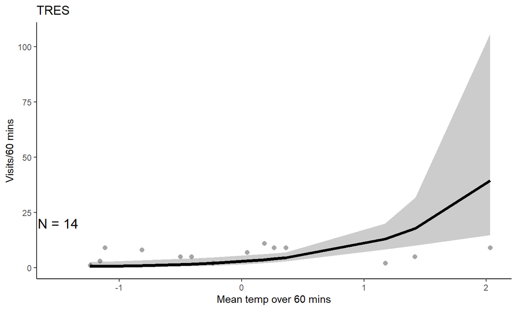

Just very few data points.

## Provisioning ~ heat * habitat, TRES, grassland

Squared term not supported

| model | Df | AIC | BIC | logLik | deviance | Chisq | Chi Df | Pr(>Chisq) |
| --- | --- | --- | --- | --- | --- | --- | --- | --- |
| no sq | 11 | 587.2223 | 613.5612 | -282.6111 | 565.2223 | NA | NA | NA |
| sq max temp | 12 | 587.2430 | 615.9764 | -281.6215 | 563.2430 | 1.979244 | 1 | 0.1594701 |

```
##  Family: nbinom2  ( log )
## Formula:
## valid_detections ~ mean_temp_scaled + julian_date_scaled + mean_nestling_age_scaled +
##     poly(tod_h_scaled, 2, raw = TRUE) + (1 | attempt_id) + year_fct
## Zero inflation:                    ~1
## Data:
## dplyr::filter(p, habitat == "Grassland", !is.na(mean_temp), !is.na(julian_date),
##     !is.na(mean_nestling_age), !is.na(tod_h), !is.na(site), !is.na(attempt_id),
##     !is.na(year), species == "TRES") %>% mutate(across(c(tod_h,
##     mean_temp, julian_date, mean_nestling_age), ~scale(.x)[,
##     1], .names = "{.col}_scaled"))
##
##      AIC      BIC   logLik deviance df.resid
##    587.2    613.6   -282.6    565.2       70
##
## Random effects:
##
## Conditional model:
##  Groups     Name        Variance Std.Dev.
##  attempt_id (Intercept) 1.63e-09 4.037e-05
## Number of obs: 81, groups:  attempt_id, 8
##
## Dispersion parameter for nbinom2 family (): 3.56
##
## Conditional model:
##                                    Estimate Std. Error z value Pr(>|z|)
## (Intercept)                         3.29613    0.22928  14.376  < 2e-16 ***
## mean_temp_scaled                    0.17966    0.17684   1.016  0.30968
## julian_date_scaled                 -0.04311    0.11172  -0.386  0.69962
## mean_nestling_age_scaled            0.27461    0.10141   2.708  0.00677 **
## poly(tod_h_scaled, 2, raw = TRUE)1 -0.02119    0.11887  -0.178  0.85852
## poly(tod_h_scaled, 2, raw = TRUE)2 -0.04391    0.13075  -0.336  0.73703
## year_fct2022                       -0.53414    0.28452  -1.877  0.06047 .
## year_fct2023                       -0.25643    0.36897  -0.695  0.48706
## ---
## Signif. codes:  0 '***' 0.001 '**' 0.01 '*' 0.05 '.' 0.1 ' ' 1
##
## Zero-inflation model:
##             Estimate Std. Error z value Pr(>|z|)
## (Intercept)  -1.4108     0.2812  -5.017 5.25e-07 ***
## ---
## Signif. codes:  0 '***' 0.001 '**' 0.01 '*' 0.05 '.' 0.1 ' ' 1
```

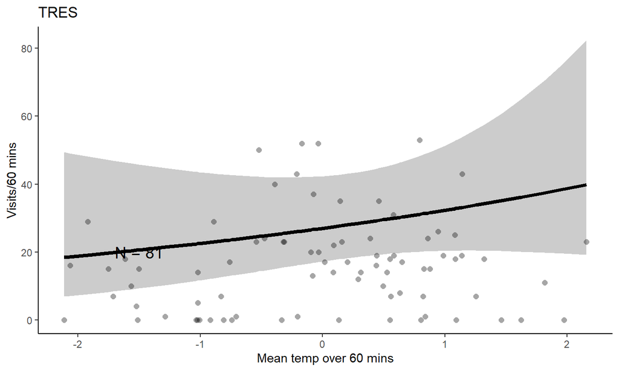

This seems oddly high.

## Provisioning ~ heat * habitat, TRES, row crop

Squared term is supported.

| model | Df | AIC | BIC | logLik | deviance | Chisq | Chi Df | Pr(>Chisq) |
| --- | --- | --- | --- | --- | --- | --- | --- | --- |
| no sq | 11 | 740.0927 | 769.1810 | -359.0464 | 718.0927 | NA | NA | NA |
| sq max temp | 12 | 738.0847 | 769.8174 | -357.0424 | 714.0847 | 4.007986 | 1 | 0.04528521 |

```
##  Family: nbinom2  ( log )
## Formula:
## valid_detections ~ poly(mean_temp_scaled, 2, raw = TRUE) + julian_date_scaled +
##     mean_nestling_age_scaled + poly(tod_h_scaled, 2, raw = TRUE) +
##     (1 | attempt_id) + year_fct
## Zero inflation:                    ~1
## Data:
## dplyr::filter(p, habitat == "Row crop", !is.na(mean_temp), !is.na(julian_date),
##     !is.na(mean_nestling_age), !is.na(tod_h), !is.na(site), !is.na(attempt_id),
##     !is.na(year), species == "TRES") %>% mutate(across(c(tod_h,
##     mean_temp, julian_date, mean_nestling_age), ~scale(.x)[,
##     1], .names = "{.col}_scaled"))
##
##      AIC      BIC   logLik deviance df.resid
##    738.1    769.8   -357.0    714.1       92
##
## Random effects:
##
## Conditional model:
##  Groups     Name        Variance  Std.Dev.
##  attempt_id (Intercept) 9.526e-10 3.086e-05
## Number of obs: 104, groups:  attempt_id, 8
##
## Dispersion parameter for nbinom2 family (): 3.93
##
## Conditional model:
##                                        Estimate Std. Error z value Pr(>|z|)
## (Intercept)                             3.03175    0.22769  13.315  < 2e-16 ***
## poly(mean_temp_scaled, 2, raw = TRUE)1  0.33841    0.09664   3.502 0.000462 ***
## poly(mean_temp_scaled, 2, raw = TRUE)2 -0.13325    0.06516  -2.045 0.040876 *
## julian_date_scaled                      0.29477    0.10915   2.701 0.006922 **
## mean_nestling_age_scaled               -0.28253    0.06741  -4.191 2.78e-05 ***
## poly(tod_h_scaled, 2, raw = TRUE)1      0.10858    0.06418   1.692 0.090703 .
## poly(tod_h_scaled, 2, raw = TRUE)2      0.27687    0.09684   2.859 0.004248 **
## year_fct2022                           -1.01197    0.25775  -3.926 8.63e-05 ***
## year_fct2023                           -0.20902    0.21713  -0.963 0.335726
## ---
## Signif. codes:  0 '***' 0.001 '**' 0.01 '*' 0.05 '.' 0.1 ' ' 1
##
## Zero-inflation model:
##             Estimate Std. Error z value Pr(>|z|)
## (Intercept)  -1.5756     0.2618  -6.018 1.76e-09 ***
## ---
## Signif. codes:  0 '***' 0.001 '**' 0.01 '*' 0.05 '.' 0.1 ' ' 1
```

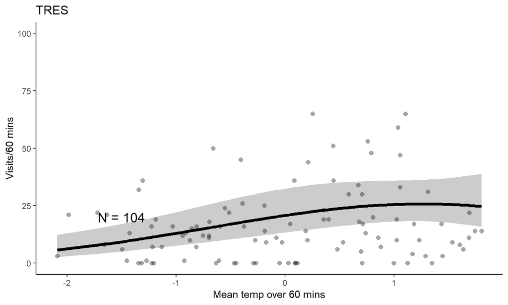

## Conclusions

Squared temp is important in row crop. Is it important to the whole model?

| Habitat | Sq temp |
| --- | --- |
| Forest |  |
| Orchard |  |
| Grassland |  |
| Row crop | * |

## Squared temp vs no squared temp, full model

It appears to not be important overall.

| model | Df | AIC | BIC | logLik | deviance | Chisq | Chi Df | Pr(>Chisq) |
| --- | --- | --- | --- | --- | --- | --- | --- | --- |
| no sq | 17 | 1613.639 | 1672.160 | -789.8195 | 1579.639 | NA | NA | NA |
| sq temp | 21 | 1616.703 | 1688.994 | -787.3515 | 1574.703 | 4.936 | 4 | 0.2939275 |

## Plot model fit for TRES

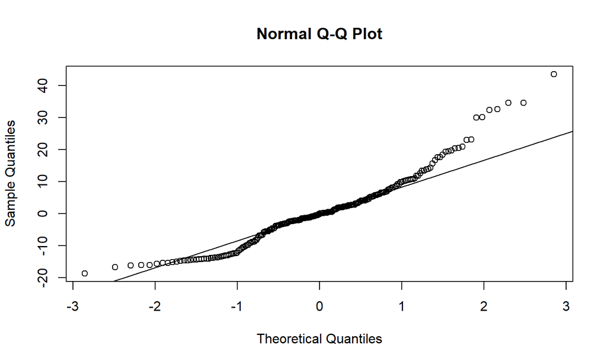

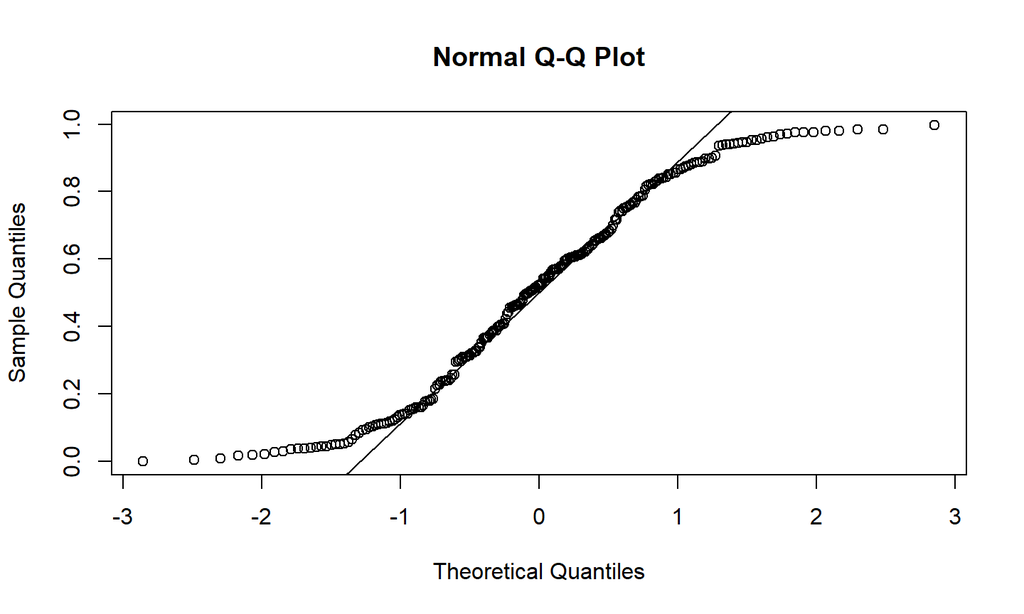

```
##        aic     bic r2.conditional r2.marginal       icc    rmse nobs
## 1 1613.639 1672.16      0.8879669   0.6083005 0.7139819 10.8111  231
```

```
## # Overdispersion test
##
##  dispersion ratio = 0.786
##           p-value = 0.648
```

```
## # Check for zero-inflation
##
##    Observed zeros: 42
##   Predicted zeros: 41
##             Ratio: 0.99
```

```
## OK: Simulated residuals appear as uniformly distributed (p = 0.859).
```

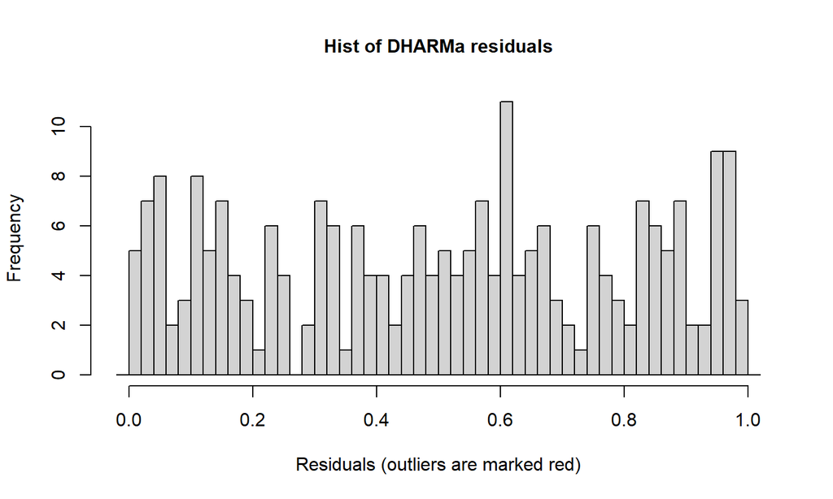

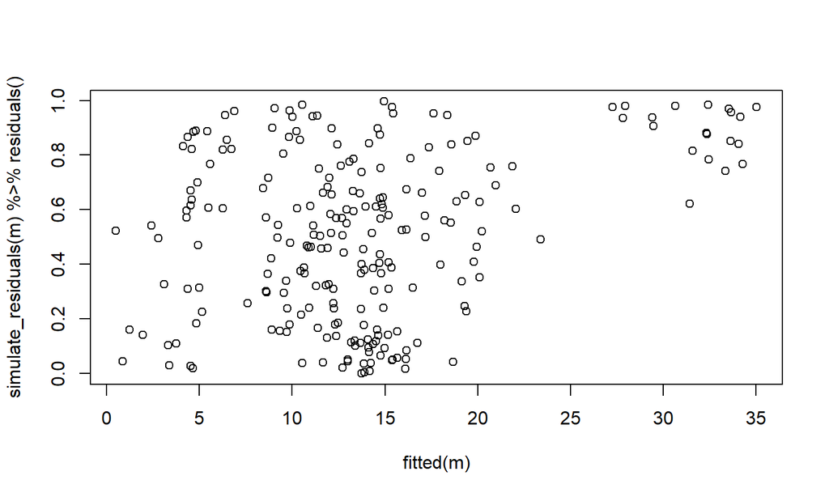

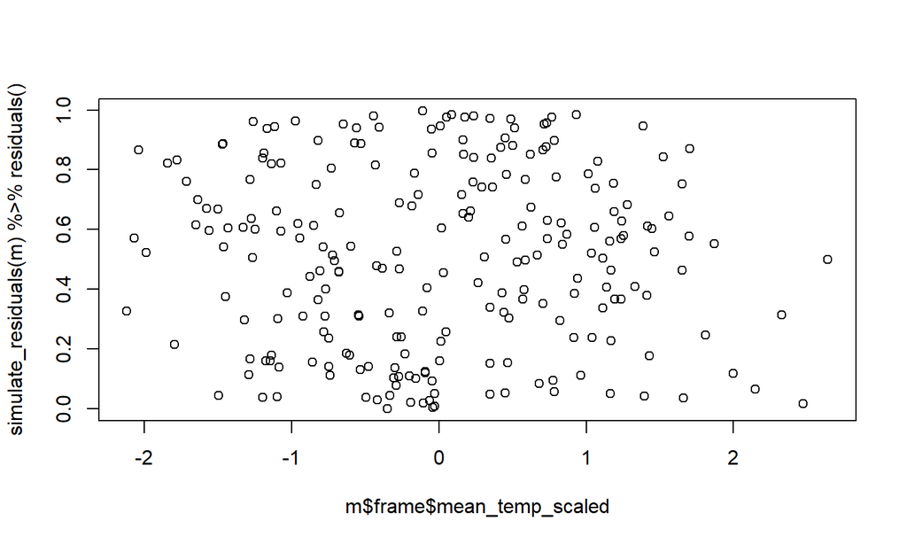

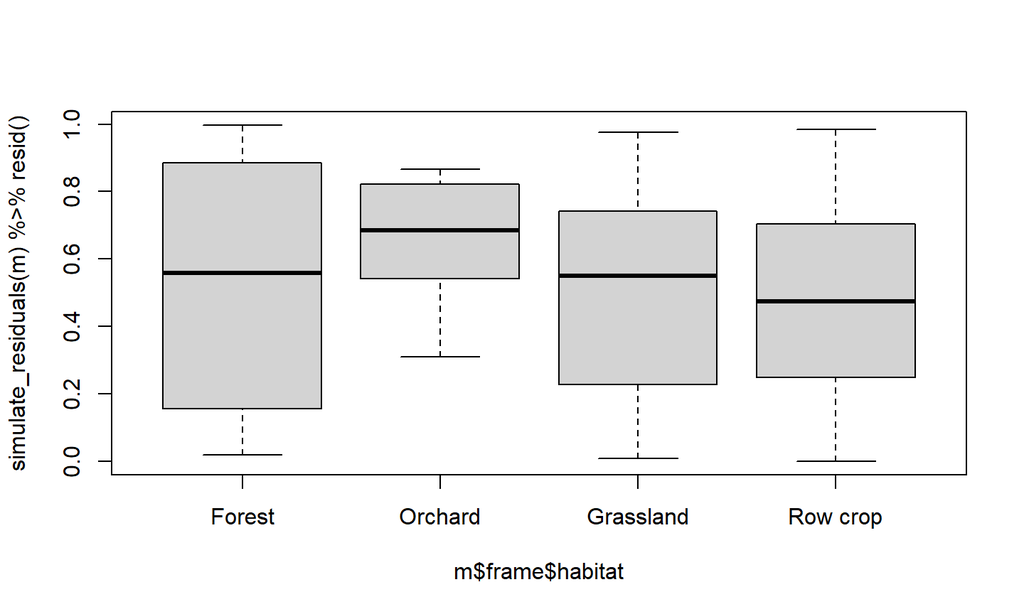

### Plot with no squared terms

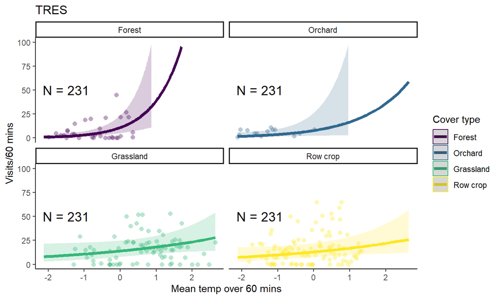

```
##  Family: nbinom2  ( log )
## Formula:
## valid_detections ~ mean_temp_scaled * habitat + julian_date_scaled +
##     mean_nestling_age_scaled + poly(tod_h_scaled, 2) + (1 | attempt_id) +
##     year_fct
## Zero inflation:                    ~1
## Data:
## dplyr::filter(p, !is.na(mean_temp), !is.na(julian_date), !is.na(mean_nestling_age),
##     !is.na(tod_h), !is.na(site), !is.na(attempt_id), !is.na(year),
##     species == "TRES") %>% mutate(across(c(tod_h, mean_temp,
##     julian_date, mean_nestling_age), ~scale(.x)[, 1], .names = "{.col}_scaled"))
##
##      AIC      BIC   logLik deviance df.resid
##   1613.6   1672.2   -789.8   1579.6      214
##
## Random effects:
##
## Conditional model:
##  Groups     Name        Variance Std.Dev.
##  attempt_id (Intercept) 0.1508   0.3883
## Number of obs: 231, groups:  attempt_id, 23
##
## Dispersion parameter for nbinom2 family ():  3.1
##
## Conditional model:
##                                   Estimate Std. Error z value Pr(>|z|)
## (Intercept)                        2.49214    0.39766   6.267 3.68e-10 ***
## mean_temp_scaled                   1.27496    0.33294   3.829 0.000128 ***
## habitatOrchard                    -0.33829    0.67713  -0.500 0.617363
## habitatGrassland                   0.24485    0.40486   0.605 0.545325
## habitatRow crop                    0.16867    0.38486   0.438 0.661197
## julian_date_scaled                -0.30857    0.13012  -2.371 0.017722 *
## mean_nestling_age_scaled           0.02780    0.07211   0.385 0.699869
## poly(tod_h_scaled, 2)1             0.66414    0.86115   0.771 0.440576
## poly(tod_h_scaled, 2)2             1.63431    1.23231   1.326 0.184770
## year_fct2022                       0.03944    0.31198   0.126 0.899398
## year_fct2023                       0.45584    0.31987   1.425 0.154133
## mean_temp_scaled:habitatOrchard   -0.50631    0.48320  -1.048 0.294722
## mean_temp_scaled:habitatGrassland -1.00986    0.32484  -3.109 0.001879 **
## mean_temp_scaled:habitatRow crop  -1.00645    0.32920  -3.057 0.002234 **
## ---
## Signif. codes:  0 '***' 0.001 '**' 0.01 '*' 0.05 '.' 0.1 ' ' 1
##
## Zero-inflation model:
##             Estimate Std. Error z value Pr(>|z|)
## (Intercept)  -1.6082     0.1917   -8.39   <2e-16 ***
## ---
## Signif. codes:  0 '***' 0.001 '**' 0.01 '*' 0.05 '.' 0.1 ' ' 1
```

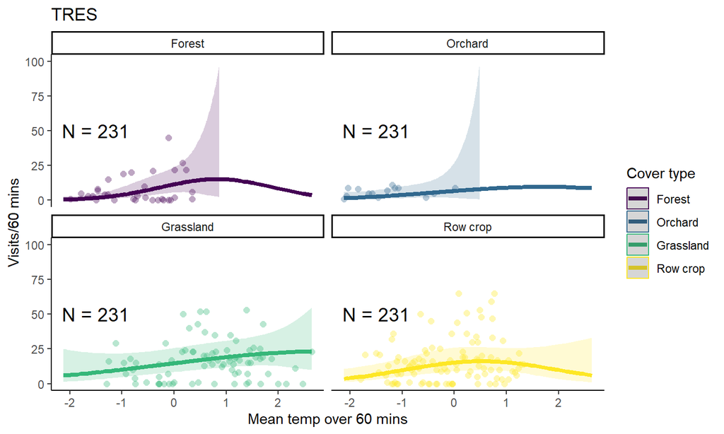

```
##  Family: nbinom2  ( log )
## Formula:
## valid_detections ~ poly(mean_temp_scaled, 2) * habitat + julian_date_scaled +
##     mean_nestling_age_scaled + poly(tod_h_scaled, 2) + (1 | attempt_id) +
##     year_fct
## Zero inflation:                    ~1
## Data:
## dplyr::filter(p, !is.na(mean_temp), !is.na(julian_date), !is.na(mean_nestling_age),
##     !is.na(tod_h), !is.na(site), !is.na(attempt_id), !is.na(year),
##     species == "TRES") %>% mutate(across(c(tod_h, mean_temp,
##     julian_date, mean_nestling_age), ~scale(.x)[, 1], .names = "{.col}_scaled"))
##
##      AIC      BIC   logLik deviance df.resid
##   1616.7   1689.0   -787.4   1574.7      210
##
## Random effects:
##
## Conditional model:
##  Groups     Name        Variance Std.Dev.
##  attempt_id (Intercept) 0.1135   0.3369
## Number of obs: 231, groups:  attempt_id, 23
##
## Dispersion parameter for nbinom2 family (): 3.23
##
## Conditional model:
##                                             Estimate Std. Error z value
## (Intercept)                                  2.14249    0.53818   3.981
## poly(mean_temp_scaled, 2)1                   9.63695   10.52871   0.915
## poly(mean_temp_scaled, 2)2                  -7.21265    7.17371  -1.005
## habitatOrchard                              -0.26505    1.14310  -0.232
## habitatGrassland                             0.59920    0.54031   1.109
## habitatRow crop                              0.46897    0.52426   0.895
## julian_date_scaled                          -0.27428    0.12398  -2.212
## mean_nestling_age_scaled                     0.03326    0.06900   0.482
## poly(tod_h_scaled, 2)1                       0.78599    0.86317   0.911
## poly(tod_h_scaled, 2)2                       1.66441    1.22447   1.359
## year_fct2022                                -0.01960    0.29141  -0.067
## year_fct2023                                 0.45694    0.29495   1.549
## poly(mean_temp_scaled, 2)1:habitatOrchard   -3.30779   20.35920  -0.162
## poly(mean_temp_scaled, 2)2:habitatOrchard    5.02869   10.72852   0.469
```

[output cut: 16 more lines]

```
## year_fct2023                                  0.1213
## poly(mean_temp_scaled, 2)1:habitatOrchard     0.8709
## poly(mean_temp_scaled, 2)2:habitatOrchard     0.6393
## poly(mean_temp_scaled, 2)1:habitatGrassland   0.6463
## poly(mean_temp_scaled, 2)2:habitatGrassland   0.3906
## poly(mean_temp_scaled, 2)1:habitatRow crop    0.5417
## poly(mean_temp_scaled, 2)2:habitatRow crop    0.6500
## ---
## Signif. codes:  0 '***' 0.001 '**' 0.01 '*' 0.05 '.' 0.1 ' ' 1
##
## Zero-inflation model:
##             Estimate Std. Error z value Pr(>|z|)
## (Intercept)  -1.5721     0.1848  -8.509   <2e-16 ***
## ---
## Signif. codes:  0 '***' 0.001 '**' 0.01 '*' 0.05 '.' 0.1 ' ' 1
```

## Overall conclusions:

Having the squared term in the model doesn’t improve fit and increases the size of standard errors… I think